# Systems Serology — SBA Effector Pathway Assessment

Scot Zens and Anja Saso

2026-07-05

# SBA Effector-Pathway Assessment

This document tests, link by link, whether the hypothesised effector pathway

$$\text{antigen IgG1/IgG3} \;\rightarrow\;
\text{Fc}\gamma\text{R binding (Fc}\gamma\text{R2a, Fc}\gamma\text{R3b)}
\;\rightarrow\; \text{ADCD} \;\rightarrow\; \textbf{SBA}$$

Antigens carried through every step: **PT, FHA, PRN** (focal chain: **PRN**). Each step is a self-contained child; run them in order.

1. **Full pathway network by arm** — one GGM per antigen containing IgG1/IgG3, both FcγRs, ADCD and the outcome, so the chain-adjacent edges become visible.
2. **Explicit link regressions with an arm interaction** — the two intermediate edges (IgG→FcγR; FcγR→ADCD) fitted directly, with a maternal-arm interaction to test whether link *strength* differs by arm.
3. **Serial mediation by arm** — a path model quantifying the IgG1 → FcγR → ADCD → outcome indirect effect.
4. **Variance decomposition by arm** — does ADCD (and FcγR) add *unique* variance beyond IgG1, or is it downstream?
5. **FcγR collinearity diagnostics** — recover the FcγR3b-specific signal that partial-correlation networks zero out.
6. **Pathway-network NCT by arm** — the arm comparison run on the FcγR+ADCD and joint-pathway networks that step-5 of the prior analysis skipped.
7. **FcγR3b unique role** — separate the two collinear receptors (residual-of-3b-on-2a, and the 2a/3b ratio) and test whether FcγR3b independently predicts ADCD and the outcome.
8. **Aggregate complement vs whole-cell outcome** — a summed antigen-specific ADCD score against the whole-cell SBA, and PRN-ADCD with quantity removed.
9. **Arm × FcγR interaction tests** — a formal test of whether the FcγR→outcome mapping differs by maternal arm (different wiring) rather than only in strength (different forcing).
10. **FcγR3b vs ADCD for the outcome** — whether FcγR3b’s link to killing survives adjustment for ADCD, adjudicating the ADCD/outcome discordance.
11. **Effector activation by FcγR** — whether each effector function (ADCD, ADCP, ADNP) is engaged by FcγR2a/FcγR3b, per antigen and arm, with the FcγR3b-specific contribution and an arm interaction.
12. **Each effector on the path to the outcome** — whether ADCP and ADNP (like ADCD) add to SBA beyond antibody quantity and beyond FcγR, and whether each survives jointly with FcγR3b.
13. **Antigen-specificity and multi-effector model** — focal PRN vs aggregate (mean-across-antigens) effector scores, and a joint ADCD+ADCP+ADNP model, to see whether any effector is independently on the path and whether the association is antigen-specific or broad.

Steps 3, 4, 7, 8, 9 and 10 run in every available data mode: **raw** (quantity), **igg_std** (all predictors residualized on total IgG — quality), and **mixed** (IgG1/IgG3 raw as the quantity exposure, FcγR & ADCD residualized as quality mediators, outcome raw). The mixed mode most directly tests “antibody amount flowing through per-antibody engagement efficiency to killing.” Available modes here: **raw, igg_std, mixed** (`igg_std`/`mixed` require the residual files).

> Interpretation is cross-sectional: these steps establish whether the pathway’s *footprint* is present and internally consistent, not causal direction. All models are complete-case; cells below 30 are skipped and logged.

# Step 1 — Full Pathway Network by Arm

For each antigen and each maternal arm, a single Gaussian graphical model (EBICglasso, partial correlations) is fit on the chain nodes **IgG1, IgG3, FcγR2a, FcγR3b, ADCD** together with **SBA**. Because all four node types sit in one graph, the edges the parallel-regression design could not show — IgG→FcγR, FcγR→ADCD, ADCD→outcome — are now directly readable. The chain-edge table isolates exactly those hypothesised adjacencies.

```r
.stage(1, "full pathway network by arm")
stopifnot(exists("path_wide"))

# partial-correlation edge between two nodes, read off the estimated graph
edge_of <- function(g, nodes, a, b) if (all(c(a, b) %in% nodes)) g[a, b] else NA_real_

chain_edges_tbl <- function(g, nodes, A) {
  o <- OUTCOME
  rows <- list(
    c(paste0(A, "_IgG1"),   paste0(A, "_FcgR2a")),
    c(paste0(A, "_IgG1"),   paste0(A, "_FcgR3b")),
    c(paste0(A, "_IgG3"),   paste0(A, "_FcgR2a")),
    c(paste0(A, "_IgG3"),   paste0(A, "_FcgR3b")),
    c(paste0(A, "_FcgR2a"), paste0(A, "_ADCD")),
    c(paste0(A, "_FcgR3b"), paste0(A, "_ADCD")),
    c(paste0(A, "_ADCD"),   o),
    c(paste0(A, "_FcgR2a"), o),
    c(paste0(A, "_FcgR3b"), o),
    c(paste0(A, "_IgG1"),   o))
  data.frame(
    link = vapply(rows, function(r) paste(sub(paste0("^", A, "_"), "", r[1]),
                                          sub(paste0("^", A, "_"), "", sub(OUTCOME, "OUTCOME", r[2])),
                                          sep = " — "), character(1)),
    partial_r = vapply(rows, function(r) round(edge_of(g, nodes, r[1], r[2]), 3), numeric(1)),
    stringsAsFactors = FALSE)
}

if (!have_net) {
  cat("*Network packages not installed; step 1 skipped.*\n\n")
} else {
  for (A in PATHWAY_ANTIGENS) {
    cat("## ", A, " pathway\n\n", sep = "")
    for (m in cfg$maternal_arms) {
      nodes <- c(chain_feats(A), OUTCOME)
      d <- arm_data(m) %>% dplyr::select(dplyr::all_of(nodes)) %>% tidyr::drop_na()
      nt_log(nt, "Pathway", paste0("Step1 net: ", A), paste0(A, " @ ", CONC_VISIT), m, nodes, arm_data(m))
      cat("### ", m, " mothers (n = ", nrow(d), ")\n\n", sep = "")
      .info("step1 %s %s network n=%d", A, m, nrow(d))
      if (nrow(d) < NETWORK_MIN) { cat(sprintf("*n < %d; skipped.*\n\n", NETWORK_MIN)); next }
      net <- tryCatch(bootnet::estimateNetwork(d, default = "EBICglasso", threshold = TRUE),
                      error = function(e) NULL)
      if (is.null(net)) { cat("*Estimation failed.*\n\n"); next }
      short <- sub(paste0("^", A, "_"), "", nodes); short[nodes == OUTCOME] <- "OUTCOME"
      grp <- list(IgG  = which(nodes %in% paste0(A, c("_IgG1", "_IgG3"))),
                  FcgR = which(nodes %in% paste0(A, c("_FcgR2a", "_FcgR3b"))),
                  ADCD = which(nodes == paste0(A, "_ADCD")),
                  OUT  = which(nodes == OUTCOME))
      qgraph::qgraph(net$graph, groups = grp, color = c("steelblue", "darkorange", "purple", "gold"),
                     labels = short, layout = "spring", vsize = 11, legend = TRUE,
                     legend.cex = 0.35, title = paste0(A, " — ", m))
      print(knitr::kable(chain_edges_tbl(net$graph, nodes, A),
                         caption = paste0("Chain-adjacent partial correlations — ", A, ", ", m,
                                          " (0 = no edge after conditioning)."),
                         col.names = c("Link", "Partial r"))); cat("\n")
    }
  }
}
```

## PT pathway

### TdaP mothers (n = 102)

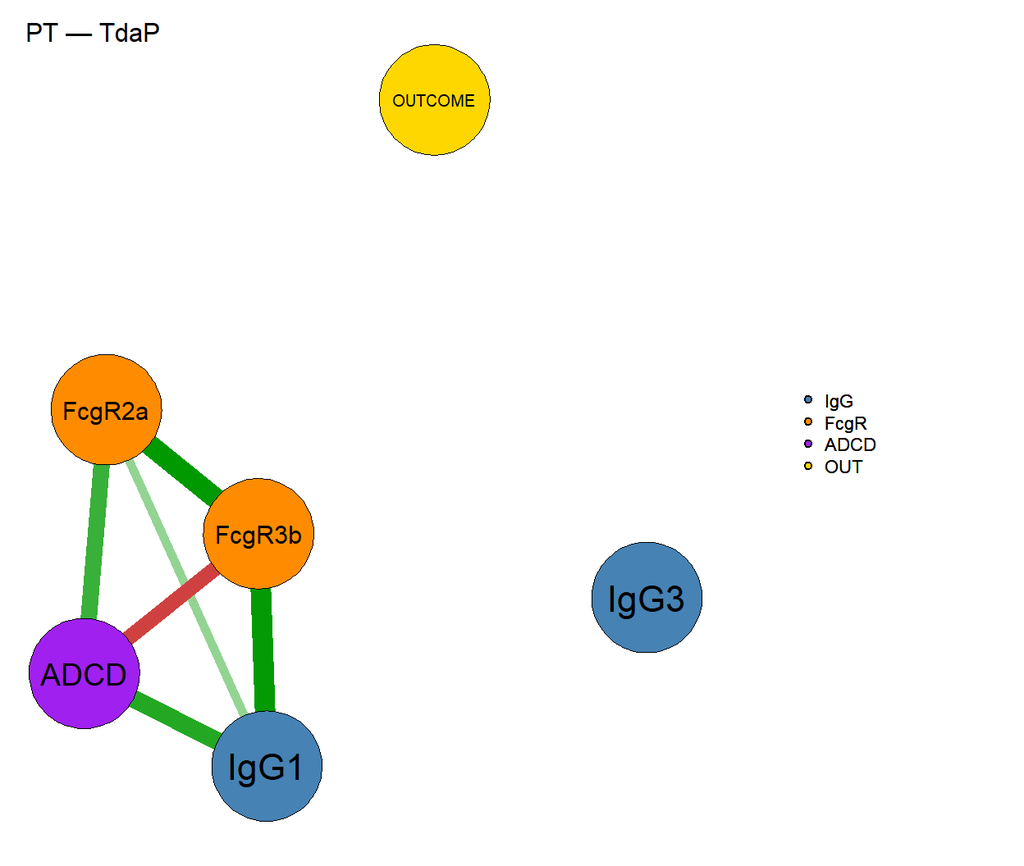

Chain-adjacent partial correlations — PT, TdaP (0 = no edge after conditioning).

| Link | Partial r |
| --- | --- |
| IgG1 — FcgR2a | 0.211 |
| IgG1 — FcgR3b | 0.490 |
| IgG3 — FcgR2a | 0.000 |
| IgG3 — FcgR3b | 0.000 |
| FcgR2a — ADCD | 0.386 |
| FcgR3b — ADCD | -0.370 |
| ADCD — OUTCOME | 0.000 |
| FcgR2a — OUTCOME | 0.000 |
| FcgR3b — OUTCOME | 0.000 |
| IgG1 — OUTCOME | 0.000 |

### TT mothers (n = 117)

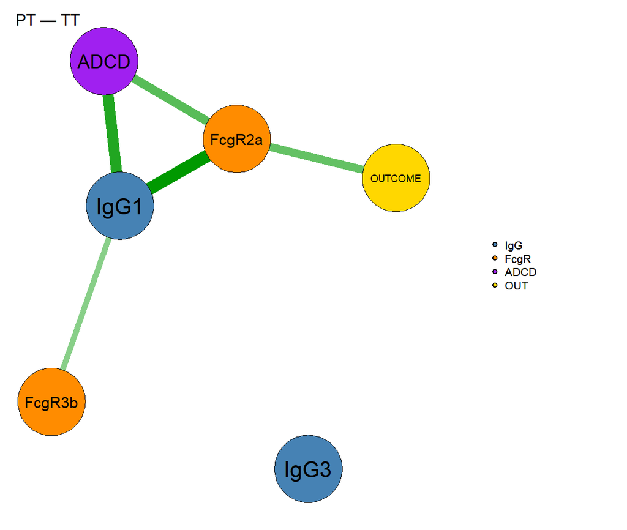

Chain-adjacent partial correlations — PT, TT (0 = no edge after conditioning).

| Link | Partial r |
| --- | --- |
| IgG1 — FcgR2a | 0.488 |
| IgG1 — FcgR3b | 0.228 |
| IgG3 — FcgR2a | 0.000 |
| IgG3 — FcgR3b | 0.000 |
| FcgR2a — ADCD | 0.320 |
| FcgR3b — ADCD | 0.000 |
| ADCD — OUTCOME | 0.000 |
| FcgR2a — OUTCOME | 0.296 |
| FcgR3b — OUTCOME | 0.000 |
| IgG1 — OUTCOME | 0.000 |

## FHA pathway

### TdaP mothers (n = 102)

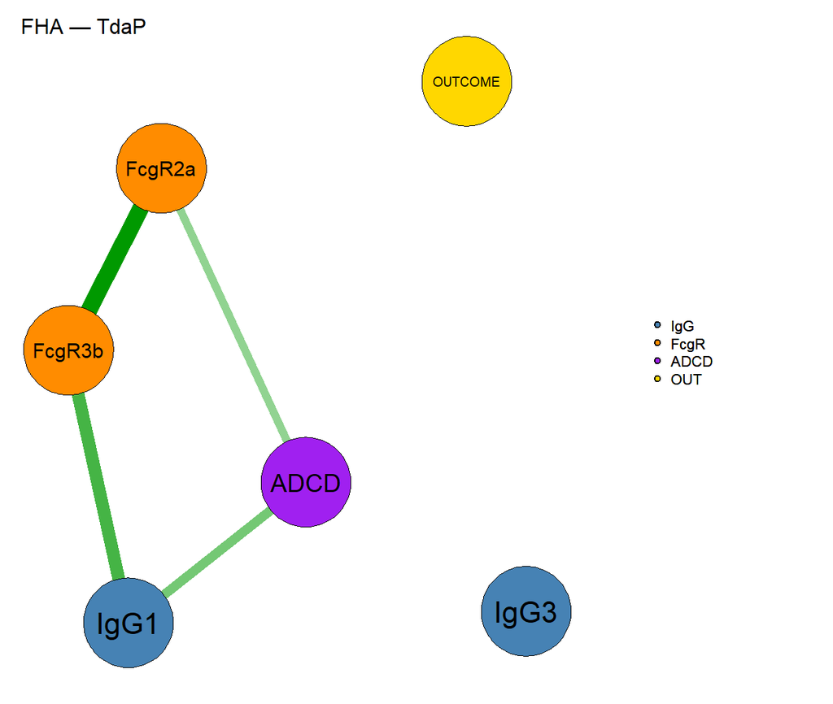

Chain-adjacent partial correlations — FHA, TdaP (0 = no edge after conditioning).

| Link | Partial r |
| --- | --- |
| IgG1 — FcgR2a | 0.000 |
| IgG1 — FcgR3b | 0.359 |
| IgG3 — FcgR2a | 0.000 |
| IgG3 — FcgR3b | 0.000 |
| FcgR2a — ADCD | 0.211 |
| FcgR3b — ADCD | 0.000 |
| ADCD — OUTCOME | 0.000 |
| FcgR2a — OUTCOME | 0.000 |
| FcgR3b — OUTCOME | 0.000 |
| IgG1 — OUTCOME | 0.000 |

### TT mothers (n = 117)

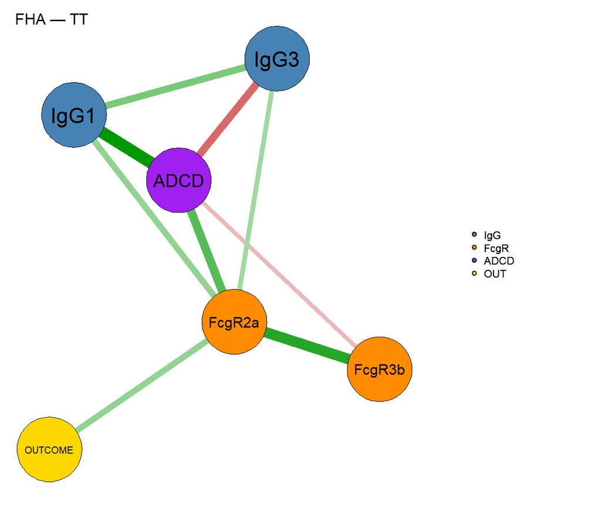

Chain-adjacent partial correlations — FHA, TT (0 = no edge after conditioning).

| Link | Partial r |
| --- | --- |
| IgG1 — FcgR2a | 0.245 |
| IgG1 — FcgR3b | 0.000 |
| IgG3 — FcgR2a | 0.213 |
| IgG3 — FcgR3b | 0.000 |
| FcgR2a — ADCD | 0.378 |
| FcgR3b — ADCD | -0.162 |
| ADCD — OUTCOME | 0.000 |
| FcgR2a — OUTCOME | 0.247 |
| FcgR3b — OUTCOME | 0.000 |
| IgG1 — OUTCOME | 0.000 |

## PRN pathway

### TdaP mothers (n = 102)

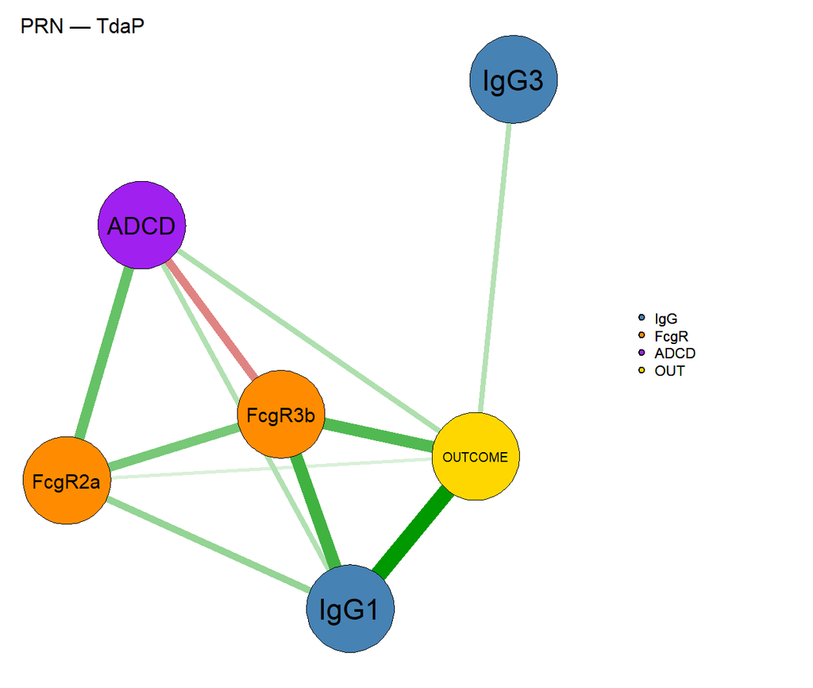

Chain-adjacent partial correlations — PRN, TdaP (0 = no edge after conditioning).

| Link | Partial r |
| --- | --- |
| IgG1 — FcgR2a | 0.206 |
| IgG1 — FcgR3b | 0.369 |
| IgG3 — FcgR2a | 0.000 |
| IgG3 — FcgR3b | 0.000 |
| FcgR2a — ADCD | 0.296 |
| FcgR3b — ADCD | -0.240 |
| ADCD — OUTCOME | 0.156 |
| FcgR2a — OUTCOME | 0.073 |
| FcgR3b — OUTCOME | 0.336 |
| IgG1 — OUTCOME | 0.492 |

### TT mothers (n = 117)

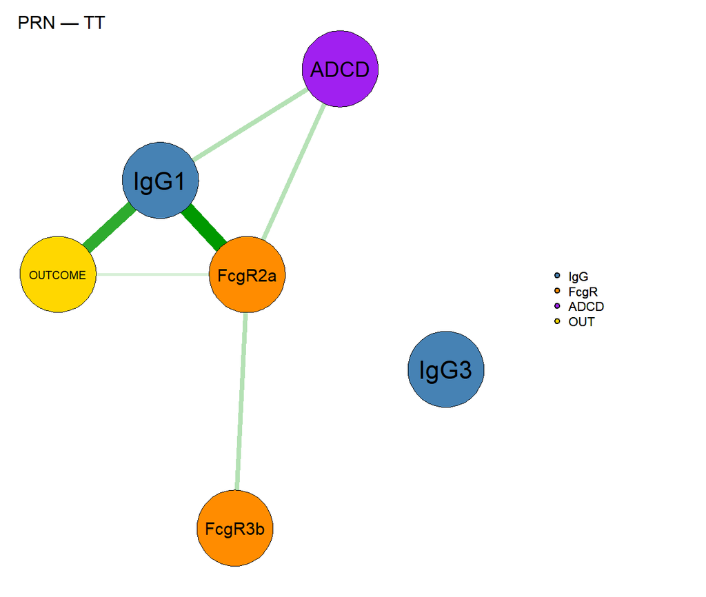

Chain-adjacent partial correlations — PRN, TT (0 = no edge after conditioning).

| Link | Partial r |
| --- | --- |
| IgG1 — FcgR2a | 0.596 |
| IgG1 — FcgR3b | 0.000 |
| IgG3 — FcgR2a | 0.000 |
| IgG3 — FcgR3b | 0.000 |
| FcgR2a — ADCD | 0.170 |
| FcgR3b — ADCD | 0.000 |
| ADCD — OUTCOME | 0.000 |
| FcgR2a — OUTCOME | 0.092 |
| FcgR3b — OUTCOME | 0.000 |
| IgG1 — OUTCOME | 0.489 |

**How to read this.** A non-zero `IgG1 — FcgR3b` edge is direct evidence of co-regulation; a non-zero `FcgR3b — ADCD` edge is evidence for the activation step; a non-zero `ADCD — OUTCOME` edge places ADCD adjacent to killing. If a chain edge is 0 while a “shortcut” edge (e.g. `IgG1 — OUTCOME`) is large, the pathway is *not* mediating and the logic needs revisiting. Compare the two arms row by row: similar signs/positions = intact in both; a link present in one arm only = arm-specific pathway.

# Step 2 — Explicit Link Regressions with Arm Interaction

The two intermediate edges are fitted directly, rather than inferred from parallel outcome regressions:

- **Link A (co-regulation):** `FcγR ~ IgG1 + IgG3` — does subclass predict receptor binding?
- **Link B (activation):** `ADCD ~ FcγR2a + FcγR3b` — does receptor binding predict complement deposition?

Each is fit **per arm**, then on the pooled data with a **maternal-arm interaction** so the slope difference (TdaP vs TT) is an explicit coefficient and p-value — the “different strengths in the two groups” question, tested rather than eyeballed. The reference arm is TdaP.

```r
.stage(2, "explicit link regressions with arm interaction")
for (A in PATHWAY_ANTIGENS) {
  cat("## ", A, "\n\n", sep = "")
  ig  <- keep_present(paste0(A, c("_IgG1", "_IgG3")))
  fcg <- keep_present(paste0(A, c("_FcgR2a", "_FcgR3b")))
  # Link A: each receptor on subclasses
  for (rc in fcg) if (length(ig)) link_report(rc, ig, paste0("Link A — ", rc, " ~ IgG1 + IgG3"))
  # Link B: ADCD on both receptors
  adcd <- paste0(A, "_ADCD")
  if (adcd %in% names(path_wide) && length(fcg))
    link_report(adcd, fcg, paste0("Link B — ", A, "_ADCD ~ FcγR2a + FcγR3b"))
}
```

## PT

#### Link A — PT_FcgR2a ~ IgG1 + IgG3

*TdaP mothers* — n = 130, R² = 0.499, adj-R² = 0.491

| term | beta | se | t | p | sig |
| --- | --- | --- | --- | --- | --- |
| (Intercept) | 0.946 | 0.282 | 3.36 | 0.00105 | ** |
| PT_IgG1 | 0.681 | 0.064 | 10.62 | 0.00000 | *** |
| PT_IgG3 | 0.206 | 0.171 | 1.20 | 0.23200 | ns |

*TT mothers* — n = 134, R² = 0.437, adj-R² = 0.428

| term | beta | se | t | p | sig |
| --- | --- | --- | --- | --- | --- |
| (Intercept) | 0.676 | 0.259 | 2.61 | 0.0101 | * |
| PT_IgG1 | 0.730 | 0.073 | 10.05 | 0.0000 | *** |
| PT_IgG3 | 0.135 | 0.146 | 0.93 | 0.3560 | ns |

*Arm-interaction terms (slope difference vs TdaP, pooled n = 264):*

| term | beta | se | t | p | sig |
| --- | --- | --- | --- | --- | --- |
| PT_IgG1 × TT | 0.049 | 0.101 | 0.49 | 0.628 | ns |
| PT_IgG3 × TT | -0.070 | 0.227 | -0.31 | 0.757 | ns |

#### Link A — PT_FcgR3b ~ IgG1 + IgG3

*TdaP mothers* — n = 130, R² = 0.572, adj-R² = 0.566

| term | beta | se | t | p | sig |
| --- | --- | --- | --- | --- | --- |
| (Intercept) | -0.028 | 0.293 | -0.10 | 0.923 | ns |
| PT_IgG1 | 0.798 | 0.067 | 11.98 | 0.000 | *** |
| PT_IgG3 | 0.409 | 0.178 | 2.30 | 0.023 | * |

*TT mothers* — n = 134, R² = 0.208, adj-R² = 0.196

| term | beta | se | t | p | sig |
| --- | --- | --- | --- | --- | --- |
| (Intercept) | 1.309 | 0.266 | 4.92 | 2.50e-06 | *** |
| PT_IgG1 | 0.437 | 0.075 | 5.86 | 0.00e+00 | *** |
| PT_IgG3 | -0.047 | 0.150 | -0.31 | 7.56e-01 | ns |

*Arm-interaction terms (slope difference vs TdaP, pooled n = 264):*

| term | beta | se | t | p | sig |
| --- | --- | --- | --- | --- | --- |
| PT_IgG1 × TT | -0.361 | 0.104 | -3.47 | 0.000611 | *** |
| PT_IgG3 × TT | -0.456 | 0.234 | -1.95 | 0.052400 | ns |

#### Link B — PT_ADCD ~ FcγR2a + FcγR3b

*TdaP mothers* — n = 128, R² = 0.318, adj-R² = 0.307

| term | beta | se | t | p | sig |
| --- | --- | --- | --- | --- | --- |
| (Intercept) | 2.334 | 0.112 | 20.90 | 0.00000 | *** |
| PT_FcgR2a | 0.373 | 0.054 | 6.88 | 0.00000 | *** |
| PT_FcgR3b | -0.143 | 0.048 | -2.97 | 0.00362 | ** |

*TT mothers* — n = 134, R² = 0.350, adj-R² = 0.341

| term | beta | se | t | p | sig |
| --- | --- | --- | --- | --- | --- |
| (Intercept) | 0.702 | 0.249 | 2.81 | 0.00565 | ** |
| PT_FcgR2a | 0.733 | 0.095 | 7.70 | 0.00000 | *** |
| PT_FcgR3b | 0.059 | 0.110 | 0.54 | 0.59200 | ns |

*Arm-interaction terms (slope difference vs TdaP, pooled n = 262):*

| term | beta | se | t | p | sig |
| --- | --- | --- | --- | --- | --- |
| PT_FcgR2a × TT | 0.360 | 0.113 | 3.19 | 0.0016 | ** |
| PT_FcgR3b × TT | 0.202 | 0.115 | 1.75 | 0.0807 | ns |

## FHA

#### Link A — FHA_FcgR2a ~ IgG1 + IgG3

*TdaP mothers* — n = 130, R² = 0.111, adj-R² = 0.097

| term | beta | se | t | p | sig |
| --- | --- | --- | --- | --- | --- |
| (Intercept) | 2.938 | 0.234 | 12.54 | 0.00000 | *** |
| FHA_IgG1 | 0.193 | 0.065 | 2.96 | 0.00364 | ** |
| FHA_IgG3 | 0.116 | 0.066 | 1.75 | 0.08250 | ns |

*TT mothers* — n = 134, R² = 0.346, adj-R² = 0.336

| term | beta | se | t | p | sig |
| --- | --- | --- | --- | --- | --- |
| (Intercept) | 1.607 | 0.183 | 8.78 | 0.0000 | *** |
| FHA_IgG1 | 0.465 | 0.064 | 7.25 | 0.0000 | *** |
| FHA_IgG3 | 0.162 | 0.094 | 1.72 | 0.0881 | ns |

*Arm-interaction terms (slope difference vs TdaP, pooled n = 264):*

| term | beta | se | t | p | sig |
| --- | --- | --- | --- | --- | --- |
| FHA_IgG1 × TT | 0.272 | 0.092 | 2.96 | 0.00338 | ** |
| FHA_IgG3 × TT | 0.046 | 0.117 | 0.39 | 0.69600 | ns |

#### Link A — FHA_FcgR3b ~ IgG1 + IgG3

*TdaP mothers* — n = 130, R² = 0.279, adj-R² = 0.267

| term | beta | se | t | p | sig |
| --- | --- | --- | --- | --- | --- |
| (Intercept) | 1.332 | 0.320 | 4.17 | 5.60e-05 | *** |
| FHA_IgG1 | 0.502 | 0.089 | 5.65 | 1.00e-07 | *** |
| FHA_IgG3 | 0.221 | 0.090 | 2.45 | 1.55e-02 | * |

*TT mothers* — n = 134, R² = 0.087, adj-R² = 0.073

| term | beta | se | t | p | sig |
| --- | --- | --- | --- | --- | --- |
| (Intercept) | 1.703 | 0.212 | 8.02 | 0.0000 | *** |
| FHA_IgG1 | 0.177 | 0.074 | 2.38 | 0.0189 | * |
| FHA_IgG3 | 0.195 | 0.109 | 1.78 | 0.0768 | ns |

*Arm-interaction terms (slope difference vs TdaP, pooled n = 264):*

| term | beta | se | t | p | sig |
| --- | --- | --- | --- | --- | --- |
| FHA_IgG1 × TT | -0.326 | 0.117 | -2.78 | 0.00578 | ** |
| FHA_IgG3 × TT | -0.026 | 0.150 | -0.18 | 0.86000 | ns |

#### Link B — FHA_ADCD ~ FcγR2a + FcγR3b

*TdaP mothers* — n = 128, R² = 0.071, adj-R² = 0.056

| term | beta | se | t | p | sig |
| --- | --- | --- | --- | --- | --- |
| (Intercept) | 2.434 | 0.211 | 11.56 | 0.0000 | *** |
| FHA_FcgR2a | 0.165 | 0.068 | 2.43 | 0.0164 | * |
| FHA_FcgR3b | 0.004 | 0.045 | 0.08 | 0.9350 | ns |

*TT mothers* — n = 134, R² = 0.322, adj-R² = 0.311

| term | beta | se | t | p | sig |
| --- | --- | --- | --- | --- | --- |
| (Intercept) | 0.786 | 0.250 | 3.15 | 0.00204 | ** |
| FHA_FcgR2a | 0.662 | 0.089 | 7.46 | 0.00000 | *** |
| FHA_FcgR3b | -0.123 | 0.090 | -1.36 | 0.17600 | ns |

*Arm-interaction terms (slope difference vs TdaP, pooled n = 262):*

| term | beta | se | t | p | sig |
| --- | --- | --- | --- | --- | --- |
| FHA_FcgR2a × TT | 0.496 | 0.116 | 4.28 | 2.69e-05 | *** |
| FHA_FcgR3b × TT | -0.127 | 0.097 | -1.31 | 1.91e-01 | ns |

## PRN

#### Link A — PRN_FcgR2a ~ IgG1 + IgG3

*TdaP mothers* — n = 130, R² = 0.645, adj-R² = 0.639

| term | beta | se | t | p | sig |
| --- | --- | --- | --- | --- | --- |
| (Intercept) | 0.803 | 0.255 | 3.16 | 0.002 | ** |
| PRN_IgG1 | 0.906 | 0.063 | 14.37 | 0.000 | *** |
| PRN_IgG3 | -0.027 | 0.167 | -0.16 | 0.870 | ns |

*TT mothers* — n = 134, R² = 0.377, adj-R² = 0.368

| term | beta | se | t | p | sig |
| --- | --- | --- | --- | --- | --- |
| (Intercept) | 0.572 | 0.333 | 1.72 | 0.0876 | ns |
| PRN_IgG1 | 1.078 | 0.126 | 8.56 | 0.0000 | *** |
| PRN_IgG3 | -0.158 | 0.239 | -0.66 | 0.5100 | ns |

*Arm-interaction terms (slope difference vs TdaP, pooled n = 264):*

| term | beta | se | t | p | sig |
| --- | --- | --- | --- | --- | --- |
| PRN_IgG1 × TT | 0.172 | 0.155 | 1.11 | 0.270 | ns |
| PRN_IgG3 × TT | -0.131 | 0.313 | -0.42 | 0.677 | ns |

#### Link A — PRN_FcgR3b ~ IgG1 + IgG3

*TdaP mothers* — n = 130, R² = 0.743, adj-R² = 0.739

| term | beta | se | t | p | sig |
| --- | --- | --- | --- | --- | --- |
| (Intercept) | -0.547 | 0.260 | -2.10 | 0.0373 | * |
| PRN_IgG1 | 1.168 | 0.064 | 18.16 | 0.0000 | *** |
| PRN_IgG3 | -0.059 | 0.170 | -0.35 | 0.7290 | ns |

*TT mothers* — n = 134, R² = 0.212, adj-R² = 0.200

| term | beta | se | t | p | sig |
| --- | --- | --- | --- | --- | --- |
| (Intercept) | 0.616 | 0.183 | 3.36 | 1.03e-03 | ** |
| PRN_IgG1 | 0.322 | 0.069 | 4.64 | 8.20e-06 | *** |
| PRN_IgG3 | 0.245 | 0.132 | 1.85 | 6.59e-02 | ns |

*Arm-interaction terms (slope difference vs TdaP, pooled n = 264):*

| term | beta | se | t | p | sig |
| --- | --- | --- | --- | --- | --- |
| PRN_IgG1 × TT | -0.846 | 0.135 | -6.25 | 0.000 | *** |
| PRN_IgG3 × TT | 0.304 | 0.273 | 1.11 | 0.266 | ns |

#### Link B — PRN_ADCD ~ FcγR2a + FcγR3b

*TdaP mothers* — n = 128, R² = 0.307, adj-R² = 0.296

| term | beta | se | t | p | sig |
| --- | --- | --- | --- | --- | --- |
| (Intercept) | 2.317 | 0.090 | 25.84 | 0.000 | *** |
| PRN_FcgR2a | 0.252 | 0.043 | 5.89 | 0.000 | *** |
| PRN_FcgR3b | -0.057 | 0.036 | -1.59 | 0.114 | ns |

*TT mothers* — n = 134, R² = 0.113, adj-R² = 0.099

| term | beta | se | t | p | sig |
| --- | --- | --- | --- | --- | --- |
| (Intercept) | 1.748 | 0.219 | 7.98 | 0.0000 | *** |
| PRN_FcgR2a | 0.229 | 0.072 | 3.17 | 0.0019 | ** |
| PRN_FcgR3b | 0.201 | 0.148 | 1.36 | 0.1760 | ns |

*Arm-interaction terms (slope difference vs TdaP, pooled n = 262):*

| term | beta | se | t | p | sig |
| --- | --- | --- | --- | --- | --- |
| PRN_FcgR2a × TT | -0.023 | 0.083 | -0.27 | 0.785 | ns |
| PRN_FcgR3b × TT | 0.258 | 0.134 | 1.92 | 0.056 | ns |

**How to read this.** A significant positive Link-A slope on `IgG1` (especially for FcγR3b) supports IgG1↔︎FcγR co-regulation; a significant Link-B slope supports FcγR-dependent ADCD. A significant `× arm` interaction means that link is genuinely stronger in one arm; a non-significant interaction means the link operates at similar strength in both, even if overall signal differs — which would argue the *model* is intact in both arms and only the inputs differ.

# Step 3 — Serial Mediation by Arm

A path model quantifying the serial indirect effect **IgG1 → FcγR → ADCD → SBA**, fit separately in each maternal arm. This is the operational test of “the pathway is intact”: if the serial indirect through FcγR3b is significant and the residual direct IgG1→outcome path is small, the chain is carrying the signal. Standardized (`std.all`) solutions are shown so paths are comparable across arms and antigens. The model is fit in each available data mode: **raw** (quantity-dominated) and, when residual files are present, **igg_std** (predictors residualized on total IgG, outcome kept raw) — the latter being the fair test of whether FcγR/ADCD mediate the outcome *independently of antibody quantity*.

```r
.stage(3, "serial mediation by arm")
med_model <- '
  fcgr2a ~ a1*igg1 + igg3
  fcgr3b ~ a2*igg1 + igg3
  adcd   ~ b1*fcgr2a + b2*fcgr3b + d*igg1
  y      ~ g*adcd + h1*fcgr2a + h2*fcgr3b + k*igg1
  ind_3b := a2*b2*g
  ind_2a := a1*b1*g
  direct := k
'
if (!RUN_MEDIATION || !have_lavaan) {
  cat("*Step 3 skipped (", if (!have_lavaan) "lavaan not installed" else "run_mediation = FALSE", ").*\n\n", sep = "")
} else {
  .modes <- if (RUN_STD_RERUNS) MODES else "raw"
  for (mode in .modes) {
    cat("## Data mode: `", mode, "`", mode_desc(mode), "\n\n", sep = "")
    wd <- wide_for(mode)
    for (A in PATHWAY_ANTIGENS) {
      need <- paste0(A, c("_IgG1", "_IgG3", "_FcgR2a", "_FcgR3b", "_ADCD"))
      if (!all(c(need, OUTCOME) %in% names(wd))) { cat("### ", A, "\n\n*Missing nodes; skipped.*\n\n", sep = ""); next }
      cat("### ", A, "\n\n", sep = "")
      for (m in cfg$maternal_arms) {
        d <- arm_data_m(mode, m) %>% dplyr::select(dplyr::all_of(c(need, OUTCOME))) %>% tidyr::drop_na()
        colnames(d) <- c("igg1", "igg3", "fcgr2a", "fcgr3b", "adcd", "y")
        d <- as.data.frame(scale(d))
        nt_log(nt, "Pathway", paste0("Step3 mediation [", mode, "]: ", A), A, m, need, arm_data_m(mode, m))
        cat("#### ", m, " mothers (n = ", nrow(d), ")\n\n", sep = "")
        .info("step3 [%s] %s %s mediation n=%d", mode, A, m, nrow(d))
        if (nrow(d) < NETWORK_MIN) { cat(sprintf("*n < %d; skipped.*\n\n", NETWORK_MIN)); next }
        fit <- tryCatch(lavaan::sem(med_model, data = d, fixed.x = FALSE), error = function(e) NULL)
        if (is.null(fit) || !lavaan::lavInspect(fit, "converged")) {
          cat("*Model did not converge.*\n\n"); next }
        ss <- lavaan::standardizedSolution(fit)
        key <- ss[ss$label %in% c("a2", "b2", "g", "k", "ind_3b", "ind_2a", "direct"),
                   c("label", "est.std", "se", "z", "pvalue")]
        names(key) <- c("path", "std_est", "se", "z", "p")
        key$path <- c(a2 = "IgG1→FcγR3b (a2)", b2 = "FcγR3b→ADCD (b2)", g = "ADCD→OUTCOME (g)",
                      k = "IgG1→OUTCOME direct (k)", ind_3b = "serial via FcγR3b (a2·b2·g)",
                      ind_2a = "serial via FcγR2a (a1·b1·g)", direct = "direct (k)")[key$path]
        key[, c("std_est", "se", "z", "p")] <- lapply(key[, c("std_est", "se", "z", "p")],
                                                       function(x) signif(x, 3))
        print(knitr::kable(key, row.names = FALSE,
                           caption = paste0("Standardized key paths — ", A, ", ", m, " [", mode, "]."))); cat("\n")
      }
    }
  }
}
```

## Data mode: `raw` — untransformed log10 (quantity)

### PT

#### TdaP mothers (n = 102)

Standardized key paths — PT, TdaP [raw].

| path | std_est | se | z | p |
| --- | --- | --- | --- | --- |
| IgG1→FcγR3b (a2) | 0.7340 | 0.0460 | 16.000 | 0.00e+00 |
| FcγR3b→ADCD (b2) | -0.5190 | 0.1010 | -5.160 | 3.00e-07 |
| ADCD→OUTCOME (g) | 0.1250 | 0.1410 | 0.884 | 3.77e-01 |
| IgG1→OUTCOME direct (k) | 0.1370 | 0.1990 | 0.691 | 4.90e-01 |
| serial via FcγR3b (a2·b2·g) | -0.0476 | 0.0548 | -0.869 | 3.85e-01 |
| serial via FcγR2a (a1·b1·g) | 0.0486 | 0.0560 | 0.868 | 3.85e-01 |
| direct (k) | 0.1370 | 0.1990 | 0.691 | 4.90e-01 |

#### TT mothers (n = 117)

Standardized key paths — PT, TT [raw].

| path | std_est | se | z | p |
| --- | --- | --- | --- | --- |
| IgG1→FcγR3b (a2) | 0.39900 | 0.0777 | 5.140 | 3.00e-07 |
| FcγR3b→ADCD (b2) | -0.17400 | 0.0584 | -2.980 | 2.84e-03 |
| ADCD→OUTCOME (g) | -0.13800 | 0.1380 | -0.998 | 3.18e-01 |
| IgG1→OUTCOME direct (k) | 0.04870 | 0.1620 | 0.300 | 7.64e-01 |
| serial via FcγR3b (a2·b2·g) | 0.00959 | 0.0103 | 0.929 | 3.53e-01 |
| serial via FcγR2a (a1·b1·g) | -0.04220 | 0.0437 | -0.966 | 3.34e-01 |
| direct (k) | 0.04870 | 0.1620 | 0.300 | 7.64e-01 |

### FHA

#### TdaP mothers (n = 102)

Standardized key paths — FHA, TdaP [raw].

| path | std_est | se | z | p |
| --- | --- | --- | --- | --- |
| IgG1→FcγR3b (a2) | 0.47100 | 0.07900 | 5.96 | 0.000 |
| FcγR3b→ADCD (b2) | -0.14400 | 0.10200 | -1.42 | 0.156 |
| ADCD→OUTCOME (g) | 0.12400 | 0.10800 | 1.15 | 0.249 |
| IgG1→OUTCOME direct (k) | 0.12600 | 0.12200 | 1.03 | 0.302 |
| serial via FcγR3b (a2·b2·g) | -0.00844 | 0.00959 | -0.88 | 0.379 |
| serial via FcγR2a (a1·b1·g) | 0.01070 | 0.01050 | 1.02 | 0.308 |
| direct (k) | 0.12600 | 0.12200 | 1.03 | 0.302 |

#### TT mothers (n = 117)

Standardized key paths — FHA, TT [raw].

| path | std_est | se | z | p |
| --- | --- | --- | --- | --- |
| IgG1→FcγR3b (a2) | 0.20100 | 0.09110 | 2.2100 | 0.0271 |
| FcγR3b→ADCD (b2) | -0.15200 | 0.05580 | -2.7200 | 0.0065 |
| ADCD→OUTCOME (g) | 0.00721 | 0.13700 | 0.0528 | 0.9580 |
| IgG1→OUTCOME direct (k) | 0.13900 | 0.13600 | 1.0200 | 0.3070 |
| serial via FcγR3b (a2·b2·g) | -0.00022 | 0.00417 | -0.0528 | 0.9580 |
| serial via FcγR2a (a1·b1·g) | 0.00187 | 0.03530 | 0.0528 | 0.9580 |
| direct (k) | 0.13900 | 0.13600 | 1.0200 | 0.3070 |

### PRN

#### TdaP mothers (n = 102)

Standardized key paths — PRN, TdaP [raw].

| path | std_est | se | z | p |
| --- | --- | --- | --- | --- |
| IgG1→FcγR3b (a2) | 0.8670 | 0.0322 | 26.90 | 0.00000 |
| FcγR3b→ADCD (b2) | -0.4060 | 0.1440 | -2.83 | 0.00471 |
| ADCD→OUTCOME (g) | 0.1000 | 0.0540 | 1.85 | 0.06410 |
| IgG1→OUTCOME direct (k) | 0.5500 | 0.0959 | 5.74 | 0.00000 |
| serial via FcγR3b (a2·b2·g) | -0.0353 | 0.0228 | -1.55 | 0.12200 |
| serial via FcγR2a (a1·b1·g) | 0.0346 | 0.0210 | 1.65 | 0.09960 |
| direct (k) | 0.5500 | 0.0959 | 5.74 | 0.00000 |

#### TT mothers (n = 117)

Standardized key paths — PRN, TT [raw].

| path | std_est | se | z | p |
| --- | --- | --- | --- | --- |
| IgG1→FcγR3b (a2) | 0.3800 | 0.08180 | 4.650 | 3.40e-06 |
| FcγR3b→ADCD (b2) | -0.0801 | 0.08700 | -0.920 | 3.57e-01 |
| ADCD→OUTCOME (g) | -0.0461 | 0.06620 | -0.696 | 4.86e-01 |
| IgG1→OUTCOME direct (k) | 0.7030 | 0.10500 | 6.730 | 0.00e+00 |
| serial via FcγR3b (a2·b2·g) | 0.0014 | 0.00255 | 0.551 | 5.82e-01 |
| serial via FcγR2a (a1·b1·g) | -0.0110 | 0.01690 | -0.653 | 5.13e-01 |
| direct (k) | 0.7030 | 0.10500 | 6.730 | 0.00e+00 |

## Data mode: `igg_std` — predictors residualized on total IgG (quality); outcome raw

### PT

#### TdaP mothers (n = 102)

Standardized key paths — PT, TdaP [igg_std].

| path | std_est | se | z | p |
| --- | --- | --- | --- | --- |
| IgG1→FcγR3b (a2) | 0.285000 | 0.0898 | 3.180 | 0.00149 |
| FcγR3b→ADCD (b2) | -0.499000 | 0.0757 | -6.590 | 0.00000 |
| ADCD→OUTCOME (g) | 0.003150 | 0.1210 | 0.026 | 0.97900 |
| IgG1→OUTCOME direct (k) | -0.074900 | 0.1080 | -0.691 | 0.48900 |
| serial via FcγR3b (a2·b2·g) | -0.000448 | 0.0172 | -0.026 | 0.97900 |
| serial via FcγR2a (a1·b1·g) | 0.000341 | 0.0131 | 0.026 | 0.97900 |
| direct (k) | -0.074900 | 0.1080 | -0.691 | 0.48900 |

#### TT mothers (n = 117)

Standardized key paths — PT, TT [igg_std].

| path | std_est | se | z | p |
| --- | --- | --- | --- | --- |
| IgG1→FcγR3b (a2) | 0.3510 | 0.0806 | 4.35 | 1.34e-05 |
| FcγR3b→ADCD (b2) | -0.3630 | 0.0860 | -4.22 | 2.39e-05 |
| ADCD→OUTCOME (g) | 0.1480 | 0.0990 | 1.49 | 1.35e-01 |
| IgG1→OUTCOME direct (k) | -0.0179 | 0.1200 | -0.15 | 8.81e-01 |
| serial via FcγR3b (a2·b2·g) | -0.0188 | 0.0142 | -1.33 | 1.85e-01 |
| serial via FcγR2a (a1·b1·g) | 0.0119 | 0.0112 | 1.06 | 2.87e-01 |
| direct (k) | -0.0179 | 0.1200 | -0.15 | 8.81e-01 |

### FHA

#### TdaP mothers (n = 102)

Standardized key paths — FHA, TdaP [igg_std].

| path | std_est | se | z | p |
| --- | --- | --- | --- | --- |
| IgG1→FcγR3b (a2) | 7.88e-02 | 0.09930 | 0.7940 | 0.427 |
| FcγR3b→ADCD (b2) | -1.50e-01 | 0.09520 | -1.5700 | 0.116 |
| ADCD→OUTCOME (g) | -6.75e-02 | 0.09980 | -0.6760 | 0.499 |
| IgG1→OUTCOME direct (k) | -9.60e-02 | 0.09740 | -0.9850 | 0.324 |
| serial via FcγR3b (a2·b2·g) | 7.96e-04 | 0.00163 | 0.4880 | 0.626 |
| serial via FcγR2a (a1·b1·g) | 3.16e-05 | 0.00108 | 0.0292 | 0.977 |
| direct (k) | -9.60e-02 | 0.09740 | -0.9850 | 0.324 |

#### TT mothers (n = 117)

Standardized key paths — FHA, TT [igg_std].

| path | std_est | se | z | p |
| --- | --- | --- | --- | --- |
| IgG1→FcγR3b (a2) | 0.18700 | 0.08770 | 2.140 | 0.03260 |
| FcγR3b→ADCD (b2) | -0.23900 | 0.07670 | -3.110 | 0.00185 |
| ADCD→OUTCOME (g) | -0.03460 | 0.09920 | -0.349 | 0.72700 |
| IgG1→OUTCOME direct (k) | 0.03590 | 0.09880 | 0.363 | 0.71700 |
| serial via FcγR3b (a2·b2·g) | 0.00155 | 0.00453 | 0.342 | 0.73200 |
| serial via FcγR2a (a1·b1·g) | -0.00493 | 0.01420 | -0.347 | 0.72900 |
| direct (k) | 0.03590 | 0.09880 | 0.363 | 0.71700 |

### PRN

#### TdaP mothers (n = 102)

Standardized key paths — PRN, TdaP [igg_std].

| path | std_est | se | z | p |
| --- | --- | --- | --- | --- |
| IgG1→FcγR3b (a2) | 0.25400 | 0.09100 | 2.790 | 0.00525 |
| FcγR3b→ADCD (b2) | -0.27300 | 0.09180 | -2.970 | 0.00297 |
| ADCD→OUTCOME (g) | 0.17000 | 0.09500 | 1.790 | 0.07420 |
| IgG1→OUTCOME direct (k) | 0.04200 | 0.09400 | 0.447 | 0.65500 |
| serial via FcγR3b (a2·b2·g) | -0.01170 | 0.00889 | -1.320 | 0.18600 |
| serial via FcγR2a (a1·b1·g) | 0.00834 | 0.00696 | 1.200 | 0.23100 |
| direct (k) | 0.04200 | 0.09400 | 0.447 | 0.65500 |

#### TT mothers (n = 117)

Standardized key paths — PRN, TT [igg_std].

| path | std_est | se | z | p |
| --- | --- | --- | --- | --- |
| IgG1→FcγR3b (a2) | 0.388000 | 0.08310 | 4.6600 | 3.10e-06 |
| FcγR3b→ADCD (b2) | -0.108000 | 0.10200 | -1.0600 | 2.90e-01 |
| ADCD→OUTCOME (g) | 0.009650 | 0.09950 | 0.0970 | 9.23e-01 |
| IgG1→OUTCOME direct (k) | 0.167000 | 0.14500 | 1.1500 | 2.50e-01 |
| serial via FcγR3b (a2·b2·g) | -0.000404 | 0.00418 | -0.0966 | 9.23e-01 |
| serial via FcγR2a (a1·b1·g) | 0.002410 | 0.02480 | 0.0969 | 9.23e-01 |
| direct (k) | 0.167000 | 0.14500 | 1.1500 | 2.50e-01 |

## Data mode: `mixed` — IgG1/IgG3 raw (quantity exposure); FcγR & ADCD residualized (quality mediators); outcome raw

### PT

#### TdaP mothers (n = 102)

Standardized key paths — PT, TdaP [mixed].

| path | std_est | se | z | p |
| --- | --- | --- | --- | --- |
| IgG1→FcγR3b (a2) | 0.32700 | 0.08780 | 3.720 | 0.000199 |
| FcγR3b→ADCD (b2) | -0.50900 | 0.07710 | -6.600 | 0.000000 |
| ADCD→OUTCOME (g) | -0.07430 | 0.11600 | -0.639 | 0.523000 |
| IgG1→OUTCOME direct (k) | 0.33000 | 0.09760 | 3.380 | 0.000715 |
| serial via FcγR3b (a2·b2·g) | 0.01230 | 0.01970 | 0.626 | 0.531000 |
| serial via FcγR2a (a1·b1·g) | -0.00404 | 0.00696 | -0.580 | 0.562000 |
| direct (k) | 0.33000 | 0.09760 | 3.380 | 0.000715 |

#### TT mothers (n = 117)

Standardized key paths — PT, TT [mixed].

| path | std_est | se | z | p |
| --- | --- | --- | --- | --- |
| IgG1→FcγR3b (a2) | -0.26400 | 0.08600 | -3.070 | 2.15e-03 |
| FcγR3b→ADCD (b2) | -0.19500 | 0.07660 | -2.540 | 1.11e-02 |
| ADCD→OUTCOME (g) | -0.08780 | 0.09860 | -0.890 | 3.73e-01 |
| IgG1→OUTCOME direct (k) | 0.47900 | 0.08870 | 5.410 | 1.00e-07 |
| serial via FcγR3b (a2·b2·g) | -0.00451 | 0.00558 | -0.808 | 4.19e-01 |
| serial via FcγR2a (a1·b1·g) | 0.00818 | 0.00986 | 0.830 | 4.07e-01 |
| direct (k) | 0.47900 | 0.08870 | 5.410 | 1.00e-07 |

### FHA

#### TdaP mothers (n = 102)

Standardized key paths — FHA, TdaP [mixed].

| path | std_est | se | z | p |
| --- | --- | --- | --- | --- |
| IgG1→FcγR3b (a2) | 0.071400 | 0.10300 | 0.693 | 0.4880 |
| FcγR3b→ADCD (b2) | -0.142000 | 0.09570 | -1.480 | 0.1380 |
| ADCD→OUTCOME (g) | -0.039300 | 0.09880 | -0.398 | 0.6900 |
| IgG1→OUTCOME direct (k) | 0.183000 | 0.09610 | 1.910 | 0.0566 |
| serial via FcγR3b (a2·b2·g) | 0.000399 | 0.00119 | 0.336 | 0.7370 |
| serial via FcγR2a (a1·b1·g) | 0.000875 | 0.00235 | 0.373 | 0.7090 |
| direct (k) | 0.183000 | 0.09610 | 1.910 | 0.0566 |

#### TT mothers (n = 117)

Standardized key paths — FHA, TT [mixed].

| path | std_est | se | z | p |
| --- | --- | --- | --- | --- |
| IgG1→FcγR3b (a2) | -0.31100 | 0.08840 | -3.520 | 0.000436 |
| FcγR3b→ADCD (b2) | -0.16500 | 0.08110 | -2.040 | 0.041800 |
| ADCD→OUTCOME (g) | -0.07370 | 0.09200 | -0.801 | 0.423000 |
| IgG1→OUTCOME direct (k) | 0.29500 | 0.08070 | 3.650 | 0.000263 |
| serial via FcγR3b (a2·b2·g) | -0.00378 | 0.00520 | -0.728 | 0.467000 |
| serial via FcγR2a (a1·b1·g) | -0.00239 | 0.00425 | -0.563 | 0.574000 |
| direct (k) | 0.29500 | 0.08070 | 3.650 | 0.000263 |

### PRN

#### TdaP mothers (n = 102)

Standardized key paths — PRN, TdaP [mixed].

| path | std_est | se | z | p |
| --- | --- | --- | --- | --- |
| IgG1→FcγR3b (a2) | 0.454000 | 0.08660 | 5.240 | 2.00e-07 |
| FcγR3b→ADCD (b2) | -0.352000 | 0.09280 | -3.800 | 1.47e-04 |
| ADCD→OUTCOME (g) | 0.031000 | 0.04860 | 0.639 | 5.23e-01 |
| IgG1→OUTCOME direct (k) | 0.866000 | 0.03060 | 28.300 | 0.00e+00 |
| serial via FcγR3b (a2·b2·g) | -0.004970 | 0.00794 | -0.625 | 5.32e-01 |
| serial via FcγR2a (a1·b1·g) | 0.000796 | 0.00150 | 0.529 | 5.96e-01 |
| direct (k) | 0.866000 | 0.03060 | 28.300 | 0.00e+00 |

#### TT mothers (n = 117)

Standardized key paths — PRN, TT [mixed].

| path | std_est | se | z | p |
| --- | --- | --- | --- | --- |
| IgG1→FcγR3b (a2) | -0.231000 | 0.093700 | -2.470 | 0.0136 |
| FcγR3b→ADCD (b2) | -0.061400 | 0.084700 | -0.726 | 0.4680 |
| ADCD→OUTCOME (g) | -0.016500 | 0.062300 | -0.264 | 0.7910 |
| IgG1→OUTCOME direct (k) | 0.796000 | 0.035500 | 22.400 | 0.0000 |
| serial via FcγR3b (a2·b2·g) | -0.000234 | 0.000947 | -0.247 | 0.8050 |
| serial via FcγR2a (a1·b1·g) | -0.000213 | 0.001050 | -0.203 | 0.8390 |
| direct (k) | 0.796000 | 0.035500 | 22.400 | 0.0000 |

**How to read this.** A significant `serial via FcγR3b (a2·b2·g)` indirect effect is direct support that the FcγR3b-specific chain transmits antibody quantity to killing. If the `direct (k)` path shrinks toward zero once the chain is in the model, mediation is (near-)complete; a large surviving direct path means routes outside ADCD also matter. Comparing arms, similar indirect magnitudes = the mechanism operates in both; a collapsed indirect in one arm = a broken link there.

# Step 4 — Variance Decomposition by Arm

For each antigen and arm, SBA is modelled by nested layers of the chain and the incremental variance is measured:

- **M1:** outcome ~ IgG1
- **M2:** + FcγR2a + FcγR3b
- **M3:** + ADCD

The key question: does **ADCD add unique variance beyond IgG1 + FcγR**, or has the FcγR layer already captured it? If ADCD’s incremental R² is ~0, ADCD behaves as a **downstream mediator** (consistent with the pathway); if it retains unique variance, it is a **partially independent** complement arm. `relaimpo` LMG shares (averaged over orderings) show each term’s unique portion in the full model.

```r
.stage(4, "variance decomposition by arm")
delta_row <- function(m0, m1, lab) {
  a <- anova(m0, m1)
  data.frame(step = lab,
             R2 = round(summary(m1)$r.squared, 3),
             dR2 = round(summary(m1)$r.squared - summary(m0)$r.squared, 3),
             F = round(a$F[2], 2), df = paste0(a$Df[2], ",", a$Res.Df[2]),
             p = signif(a$`Pr(>F)`[2], 3), stringsAsFactors = FALSE)
}
.modes <- if (RUN_STD_RERUNS) MODES else "raw"
for (mode in .modes) {
  cat("# Data mode: `", mode, "`", mode_desc(mode), "\n\n", sep = "")
  wd <- wide_for(mode)
  for (A in PATHWAY_ANTIGENS) {
    cat("## ", A, "\n\n", sep = "")
    igg1 <- paste0(A, "_IgG1"); fcg <- intersect(paste0(A, c("_FcgR2a", "_FcgR3b")), names(wd))
    adcd <- paste0(A, "_ADCD")
    vars <- intersect(c(igg1, fcg, adcd), names(wd))
    if (!(igg1 %in% names(wd)) || !length(fcg) || !(adcd %in% names(wd)) || !(OUTCOME %in% names(wd))) {
      cat("*Incomplete chain; skipped.*\n\n"); next }
    for (m in cfg$maternal_arms) {
      d <- arm_data_m(mode, m) %>% dplyr::select(dplyr::all_of(c(OUTCOME, vars))) %>% tidyr::drop_na()
      cat("### ", m, " mothers (n = ", nrow(d), ")\n\n", sep = "")
      .info("step4 [%s] %s %s n=%d", mode, A, m, nrow(d))
      if (nrow(d) < NETWORK_MIN) { cat(sprintf("*n < %d; skipped.*\n\n", NETWORK_MIN)); next }
      m1 <- lm(reformulate(igg1,          response = OUTCOME), data = d)
      m2 <- lm(reformulate(c(igg1, fcg),  response = OUTCOME), data = d)
      m3 <- lm(reformulate(vars,          response = OUTCOME), data = d)
      tab <- rbind(
        data.frame(step = "M1: IgG1", R2 = round(summary(m1)$r.squared, 3),
                   dR2 = round(summary(m1)$r.squared, 3), F = NA, df = "", p = NA),
        delta_row(m1, m2, "M2: + FcγR2a/3b"),
        delta_row(m2, m3, "M3: + ADCD"))
      print(knitr::kable(tab, row.names = FALSE,
                         caption = paste0("Incremental variance — ", A, ", ", m, " [", mode, "]."))); cat("\n")
      if (have_relimp && nrow(d) > length(vars) + 2) {
        ri <- tryCatch(relaimpo::calc.relimp(m3, type = "lmg", rela = FALSE), error = function(e) NULL)
        if (!is.null(ri)) {
          lm_tab <- data.frame(term = names(ri@lmg), unique_R2_lmg = round(ri@lmg, 3),
                               row.names = NULL)
          lm_tab <- lm_tab[order(-lm_tab$unique_R2_lmg), ]
          print(knitr::kable(lm_tab, row.names = FALSE,
                             caption = paste0("LMG unique-variance shares (full M3) — ", A, ", ", m, " [", mode, "]."))); cat("\n")
        }
      }
    }
  }
}
```

# Data mode: `raw` — untransformed log10 (quantity)

## PT

### TdaP mothers (n = 102)

Incremental variance — PT, TdaP [raw].

| step | R2 | dR2 | F | df | p |
| --- | --- | --- | --- | --- | --- |
| M1: IgG1 | 0.089 | 0.089 | NA |  | NA |
| M2: + FcγR2a/3b | 0.096 | 0.007 | 0.39 | 2,98 | 0.676 |
| M3: + ADCD | 0.103 | 0.007 | 0.74 | 1,97 | 0.392 |

LMG unique-variance shares (full M3) — PT, TdaP [raw].

| term | unique_R2_lmg |
| --- | --- |
| PT_IgG1 | 0.034 |
| PT_FcgR3b | 0.033 |
| PT_FcgR2a | 0.018 |
| PT_ADCD | 0.018 |

### TT mothers (n = 117)

Incremental variance — PT, TT [raw].

| step | R2 | dR2 | F | df | p |
| --- | --- | --- | --- | --- | --- |
| M1: IgG1 | 0.166 | 0.166 | NA |  | NA |
| M2: + FcγR2a/3b | 0.259 | 0.093 | 7.13 | 2,113 | 0.00122 |
| M3: + ADCD | 0.266 | 0.006 | 0.95 | 1,112 | 0.33200 |

LMG unique-variance shares (full M3) — PT, TT [raw].

| term | unique_R2_lmg |
| --- | --- |
| PT_FcgR2a | 0.157 |
| PT_IgG1 | 0.062 |
| PT_ADCD | 0.040 |
| PT_FcgR3b | 0.007 |

## FHA

### TdaP mothers (n = 102)

Incremental variance — FHA, TdaP [raw].

| step | R2 | dR2 | F | df | p |
| --- | --- | --- | --- | --- | --- |
| M1: IgG1 | 0.040 | 0.040 | NA |  | NA |
| M2: + FcγR2a/3b | 0.046 | 0.005 | 0.26 | 2,98 | 0.770 |
| M3: + ADCD | 0.058 | 0.012 | 1.25 | 1,97 | 0.267 |

LMG unique-variance shares (full M3) — FHA, TdaP [raw].

| term | unique_R2_lmg |
| --- | --- |
| FHA_IgG1 | 0.024 |
| FHA_ADCD | 0.018 |
| FHA_FcgR3b | 0.013 |
| FHA_FcgR2a | 0.003 |

### TT mothers (n = 117)

Incremental variance — FHA, TT [raw].

| step | R2 | dR2 | F | df | p |
| --- | --- | --- | --- | --- | --- |
| M1: IgG1 | 0.156 | 0.156 | NA |  | NA |
| M2: + FcγR2a/3b | 0.228 | 0.072 | 5.27 | 2,113 | 0.0065 |
| M3: + ADCD | 0.228 | 0.000 | 0.00 | 1,112 | 0.9590 |

LMG unique-variance shares (full M3) — FHA, TT [raw].

| term | unique_R2_lmg |
| --- | --- |
| FHA_FcgR2a | 0.096 |
| FHA_IgG1 | 0.063 |
| FHA_ADCD | 0.049 |
| FHA_FcgR3b | 0.021 |

## PRN

### TdaP mothers (n = 102)

Incremental variance — PRN, TdaP [raw].

| step | R2 | dR2 | F | df | p |
| --- | --- | --- | --- | --- | --- |
| M1: IgG1 | 0.794 | 0.794 | NA |  | NA |
| M2: + FcγR2a/3b | 0.819 | 0.026 | 6.94 | 2,98 | 0.00152 |
| M3: + ADCD | 0.825 | 0.006 | 3.30 | 1,97 | 0.07230 |

LMG unique-variance shares (full M3) — PRN, TdaP [raw].

| term | unique_R2_lmg |
| --- | --- |
| PRN_IgG1 | 0.319 |
| PRN_FcgR3b | 0.256 |
| PRN_FcgR2a | 0.169 |
| PRN_ADCD | 0.082 |

### TT mothers (n = 117)

Incremental variance — PRN, TT [raw].

| step | R2 | dR2 | F | df | p |
| --- | --- | --- | --- | --- | --- |
| M1: IgG1 | 0.627 | 0.627 | NA |  | NA |
| M2: + FcγR2a/3b | 0.633 | 0.006 | 0.98 | 2,113 | 0.379 |
| M3: + ADCD | 0.635 | 0.002 | 0.46 | 1,112 | 0.497 |

LMG unique-variance shares (full M3) — PRN, TT [raw].

| term | unique_R2_lmg |
| --- | --- |
| PRN_IgG1 | 0.333 |
| PRN_FcgR2a | 0.203 |
| PRN_FcgR3b | 0.055 |
| PRN_ADCD | 0.044 |

# Data mode: `igg_std` — predictors residualized on total IgG (quality); outcome raw

## PT

### TdaP mothers (n = 102)

Incremental variance — PT, TdaP [igg_std].

| step | R2 | dR2 | F | df | p |
| --- | --- | --- | --- | --- | --- |
| M1: IgG1 | 0.006 | 0.006 | NA |  | NA |
| M2: + FcγR2a/3b | 0.027 | 0.021 | 1.08 | 2,98 | 0.344 |
| M3: + ADCD | 0.027 | 0.000 | 0.00 | 1,97 | 0.980 |

LMG unique-variance shares (full M3) — PT, TdaP [igg_std].

| term | unique_R2_lmg |
| --- | --- |
| PT_FcgR2a | 0.011 |
| PT_FcgR3b | 0.008 |
| PT_IgG1 | 0.005 |
| PT_ADCD | 0.003 |

### TT mothers (n = 117)

Incremental variance — PT, TT [igg_std].

| step | R2 | dR2 | F | df | p |
| --- | --- | --- | --- | --- | --- |
| M1: IgG1 | 0.005 | 0.005 | NA |  | NA |
| M2: + FcγR2a/3b | 0.055 | 0.050 | 2.99 | 2,113 | 0.0543 |
| M3: + ADCD | 0.072 | 0.017 | 2.10 | 1,112 | 0.1500 |

LMG unique-variance shares (full M3) — PT, TT [igg_std].

| term | unique_R2_lmg |
| --- | --- |
| PT_ADCD | 0.030 |
| PT_FcgR2a | 0.020 |
| PT_FcgR3b | 0.019 |
| PT_IgG1 | 0.003 |

## FHA

### TdaP mothers (n = 102)

Incremental variance — FHA, TdaP [igg_std].

| step | R2 | dR2 | F | df | p |
| --- | --- | --- | --- | --- | --- |
| M1: IgG1 | 0.008 | 0.008 | NA |  | NA |
| M2: + FcγR2a/3b | 0.034 | 0.026 | 1.33 | 2,98 | 0.268 |
| M3: + ADCD | 0.039 | 0.004 | 0.43 | 1,97 | 0.512 |

LMG unique-variance shares (full M3) — FHA, TdaP [igg_std].

| term | unique_R2_lmg |
| --- | --- |
| FHA_FcgR2a | 0.023 |
| FHA_IgG1 | 0.008 |
| FHA_ADCD | 0.005 |
| FHA_FcgR3b | 0.002 |

### TT mothers (n = 117)

Incremental variance — FHA, TT [igg_std].

| step | R2 | dR2 | F | df | p |
| --- | --- | --- | --- | --- | --- |
| M1: IgG1 | 0.003 | 0.003 | NA |  | NA |
| M2: + FcγR2a/3b | 0.140 | 0.137 | 8.99 | 2,113 | 0.000238 |
| M3: + ADCD | 0.141 | 0.001 | 0.12 | 1,112 | 0.734000 |

LMG unique-variance shares (full M3) — FHA, TT [igg_std].

| term | unique_R2_lmg |
| --- | --- |
| FHA_FcgR3b | 0.100 |
| FHA_FcgR2a | 0.033 |
| FHA_ADCD | 0.004 |
| FHA_IgG1 | 0.003 |

## PRN

### TdaP mothers (n = 102)

Incremental variance — PRN, TdaP [igg_std].

| step | R2 | dR2 | F | df | p |
| --- | --- | --- | --- | --- | --- |
| M1: IgG1 | 0.011 | 0.011 | NA |  | NA |
| M2: + FcγR2a/3b | 0.147 | 0.136 | 7.80 | 2,98 | 0.000717 |
| M3: + ADCD | 0.173 | 0.025 | 2.97 | 1,97 | 0.087800 |

LMG unique-variance shares (full M3) — PRN, TdaP [igg_std].

| term | unique_R2_lmg |
| --- | --- |
| PRN_FcgR3b | 0.146 |
| PRN_ADCD | 0.012 |
| PRN_FcgR2a | 0.008 |
| PRN_IgG1 | 0.006 |

### TT mothers (n = 117)

Incremental variance — PRN, TT [igg_std].

| step | R2 | dR2 | F | df | p |
| --- | --- | --- | --- | --- | --- |
| M1: IgG1 | 0.004 | 0.004 | NA |  | NA |
| M2: + FcγR2a/3b | 0.036 | 0.031 | 1.82 | 2,113 | 0.166 |
| M3: + ADCD | 0.036 | 0.000 | 0.01 | 1,112 | 0.925 |

LMG unique-variance shares (full M3) — PRN, TT [igg_std].

| term | unique_R2_lmg |
| --- | --- |
| PRN_FcgR3b | 0.023 |
| PRN_IgG1 | 0.009 |
| PRN_FcgR2a | 0.002 |
| PRN_ADCD | 0.001 |

# Data mode: `mixed` — IgG1/IgG3 raw (quantity exposure); FcγR & ADCD residualized (quality mediators); outcome raw

## PT

### TdaP mothers (n = 102)

Incremental variance — PT, TdaP [mixed].

| step | R2 | dR2 | F | df | p |
| --- | --- | --- | --- | --- | --- |
| M1: IgG1 | 0.089 | 0.089 | NA |  | NA |
| M2: + FcγR2a/3b | 0.111 | 0.023 | 1.24 | 2,98 | 0.293 |
| M3: + ADCD | 0.115 | 0.004 | 0.39 | 1,97 | 0.535 |

LMG unique-variance shares (full M3) — PT, TdaP [mixed].

| term | unique_R2_lmg |
| --- | --- |
| PT_IgG1 | 0.092 |
| PT_FcgR2a | 0.014 |
| PT_ADCD | 0.005 |
| PT_FcgR3b | 0.004 |

### TT mothers (n = 117)

Incremental variance — PT, TT [mixed].

| step | R2 | dR2 | F | df | p |
| --- | --- | --- | --- | --- | --- |
| M1: IgG1 | 0.166 | 0.166 | NA |  | NA |
| M2: + FcγR2a/3b | 0.234 | 0.068 | 5.01 | 2,113 | 0.0082 |
| M3: + ADCD | 0.239 | 0.005 | 0.76 | 1,112 | 0.3860 |

LMG unique-variance shares (full M3) — PT, TT [mixed].

| term | unique_R2_lmg |
| --- | --- |
| PT_IgG1 | 0.163 |
| PT_FcgR2a | 0.044 |
| PT_ADCD | 0.020 |
| PT_FcgR3b | 0.013 |

## FHA

### TdaP mothers (n = 102)

Incremental variance — FHA, TdaP [mixed].

| step | R2 | dR2 | F | df | p |
| --- | --- | --- | --- | --- | --- |
| M1: IgG1 | 0.040 | 0.040 | NA |  | NA |
| M2: + FcγR2a/3b | 0.060 | 0.019 | 1.01 | 2,98 | 0.369 |
| M3: + ADCD | 0.061 | 0.001 | 0.15 | 1,97 | 0.699 |

LMG unique-variance shares (full M3) — FHA, TdaP [mixed].

| term | unique_R2_lmg |
| --- | --- |
| FHA_IgG1 | 0.036 |
| FHA_FcgR2a | 0.020 |
| FHA_ADCD | 0.003 |
| FHA_FcgR3b | 0.002 |

### TT mothers (n = 117)

Incremental variance — FHA, TT [mixed].

| step | R2 | dR2 | F | df | p |
| --- | --- | --- | --- | --- | --- |
| M1: IgG1 | 0.156 | 0.156 | NA |  | NA |
| M2: + FcγR2a/3b | 0.212 | 0.055 | 3.96 | 2,113 | 0.0218 |
| M3: + ADCD | 0.216 | 0.004 | 0.61 | 1,112 | 0.4350 |

LMG unique-variance shares (full M3) — FHA, TT [mixed].

| term | unique_R2_lmg |
| --- | --- |
| FHA_IgG1 | 0.120 |
| FHA_FcgR3b | 0.067 |
| FHA_FcgR2a | 0.024 |
| FHA_ADCD | 0.004 |

## PRN

### TdaP mothers (n = 102)

Incremental variance — PRN, TdaP [mixed].

| step | R2 | dR2 | F | df | p |
| --- | --- | --- | --- | --- | --- |
| M1: IgG1 | 0.794 | 0.794 | NA |  | NA |
| M2: + FcγR2a/3b | 0.798 | 0.004 | 1.05 | 2,98 | 0.355 |
| M3: + ADCD | 0.799 | 0.001 | 0.39 | 1,97 | 0.534 |

LMG unique-variance shares (full M3) — PRN, TdaP [mixed].

| term | unique_R2_lmg |
| --- | --- |
| PRN_IgG1 | 0.716 |
| PRN_FcgR3b | 0.074 |
| PRN_FcgR2a | 0.004 |
| PRN_ADCD | 0.004 |

### TT mothers (n = 117)

Incremental variance — PRN, TT [mixed].

| step | R2 | dR2 | F | df | p |
| --- | --- | --- | --- | --- | --- |
| M1: IgG1 | 0.627 | 0.627 | NA |  | NA |
| M2: + FcγR2a/3b | 0.627 | 0.000 | 0.05 | 2,113 | 0.951 |
| M3: + ADCD | 0.627 | 0.000 | 0.07 | 1,112 | 0.796 |

LMG unique-variance shares (full M3) — PRN, TT [mixed].

| term | unique_R2_lmg |
| --- | --- |
| PRN_IgG1 | 0.617 |
| PRN_FcgR3b | 0.008 |
| PRN_FcgR2a | 0.002 |
| PRN_ADCD | 0.001 |

**How to read this.** Focus on the `M3: + ADCD` row: a small, non-significant ΔR² means ADCD adds little once IgG1+FcγR are present — the expected footprint of a mediator sitting *between* FcγR and the outcome. A large significant ΔR² means ADCD carries information the binding measures miss. Read the two arms together: the same ordering (IgG1 large, FcγR incremental, ADCD near-zero) appearing in both arms is strong evidence the mechanism’s *shape* is arm-invariant.

# Step 5 — FcγR Collinearity Diagnostics

In the earlier partial-correlation networks every FcγR3b node dropped to zero — the signature of FcγR2a and FcγR3b being near-collinear, so conditioning on one erases its twin. That is a modelling artifact, not evidence FcγR3b is unimportant. This step recovers the **FcγR3b-specific** signal you care about by reporting, per antigen and arm: the receptor–receptor correlation, the variance inflation, and — crucially — FcγR3b’s **zero-order** associations (with the outcome, with IgG1, with ADCD) beside its **partial** association after adjusting for FcγR2a.

```r
.stage(5, "FcγR collinearity diagnostics")
rows <- list()
for (A in PATHWAY_ANTIGENS) {
  r2a <- paste0(A, "_FcgR2a"); r3b <- paste0(A, "_FcgR3b")
  igg1 <- paste0(A, "_IgG1"); adcd <- paste0(A, "_ADCD")
  if (!all(c(r2a, r3b, igg1) %in% names(path_wide))) next
  for (m in cfg$maternal_arms) {
    need <- keep_present(c(OUTCOME, r2a, r3b, igg1, adcd))
    d <- arm_data(m) %>% dplyr::select(dplyr::all_of(need)) %>% tidyr::drop_na()
    if (nrow(d) < 20) next
    .info("step5 %s %s n=%d", A, m, nrow(d))
    rows[[length(rows) + 1]] <- data.frame(
      antigen = A, arm = m, n = nrow(d),
      cor_2a_3b     = round(cor(d[[r2a]], d[[r3b]]), 3),
      VIF_3b        = round(vif2(d, r3b, r2a, igg1), 2),
      r_3b_OUT      = round(cor(d[[r3b]], d[[OUTCOME]]), 3),
      pr_3b_OUT_2a  = round(pcor_resid(d, r3b, OUTCOME, r2a), 3),
      r_3b_IgG1     = round(cor(d[[r3b]], d[[igg1]]), 3),
      r_3b_ADCD     = if (adcd %in% names(d)) round(cor(d[[r3b]], d[[adcd]]), 3) else NA_real_,
      stringsAsFactors = FALSE)
  }
}
diag_tbl <- do.call(rbind, rows)
if (is.null(diag_tbl)) {
  cat("*No antigen had a complete FcγR pair; step 5 skipped.*\n\n")
} else {
  print(knitr::kable(diag_tbl, row.names = FALSE,
    caption = "FcγR collinearity and FcγR3b-specific associations (zero-order r vs partial pr | FcγR2a).",
    col.names = c("Antigen", "Arm", "n", "r(2a,3b)", "VIF 3b", "r(3b,OUT)",
                  "pr(3b,OUT|2a)", "r(3b,IgG1)", "r(3b,ADCD)")))
  cat("\n")
}
```

FcγR collinearity and FcγR3b-specific associations (zero-order r vs partial pr | FcγR2a).

| Antigen | Arm | n | r(2a,3b) | VIF 3b | r(3b,OUT) | pr(3b,OUT\|2a) | r(3b,IgG1) | r(3b,ADCD) |
| --- | --- | --- | --- | --- | --- | --- | --- | --- |
| PT | TdaP | 102 | 0.756 | 2.82 | 0.280 | 0.150 | 0.755 | 0.322 |
| PT | TT | 117 | 0.358 | 1.19 | 0.150 | -0.040 | 0.399 | 0.174 |
| FHA | TdaP | 102 | 0.597 | 1.88 | 0.154 | 0.144 | 0.516 | 0.206 |
| FHA | TT | 117 | 0.511 | 1.41 | 0.020 | -0.243 | 0.254 | 0.177 |
| PRN | TdaP | 102 | 0.745 | 3.88 | 0.838 | 0.635 | 0.851 | 0.383 |
| PRN | TT | 117 | 0.462 | 1.29 | 0.410 | 0.135 | 0.444 | 0.186 |

**How to read this.** A high `r(2a,3b)` (say > 0.8) and `VIF 3b` well above ~5 confirm the receptors are redundant, explaining why the joint network zeroed FcγR3b. The informative columns are the zero-order associations: a solid `r(3b,IgG1)` supports IgG1↔︎FcγR3b co-regulation, a solid `r(3b,ADCD)` supports the FcγR3b→ADCD step, and `r(3b,OUT)` its link to killing — none of which the partialled network could show. If `pr(3b,OUT|2a)` collapses toward 0 while `r(3b,OUT)` is large, the two receptors are interchangeable carriers of the same signal, and FcγR3b-specific claims should rest on the zero-order / single-receptor evidence rather than the joint model. Consistent patterns across arms indicate the redundancy (and the underlying signal) is arm-invariant.

# Step 6 — Pathway-Network NCT by Arm

The prior analysis compared only the *subclass* network across arms and found it invariant. Here the arm comparison (TdaP vs TT, 1000 permutations) is run on the **pathway-relevant** networks it skipped: the full **FcγR + ADCD** network, and the **focal PRN chain** network (IgG1/IgG3 + both FcγRs + ADCD + outcome). Structure invariance (M) tests whether the wiring differs; global-strength invariance (S) tests whether overall connectivity differs.

```r
.stage(6, sprintf("pathway-network NCT by arm (it = %d)", NCT_IT))
nct_pair <- function(nodes, label) {
  nodes <- keep_present(nodes)
  d1 <- arm_data(cfg$maternal_arms[1]) %>% dplyr::select(dplyr::all_of(nodes)) %>% tidyr::drop_na()
  d2 <- arm_data(cfg$maternal_arms[2]) %>% dplyr::select(dplyr::all_of(nodes)) %>% tidyr::drop_na()
  cat("## ", label, "\n\n", sep = "")
  cat(sprintf("%s n = %d; %s n = %d; %d nodes.\n\n",
              cfg$maternal_arms[1], nrow(d1), cfg$maternal_arms[2], nrow(d2), length(nodes)))
  .info("step6 NCT %-28s n1=%d n2=%d nodes=%d", label, nrow(d1), nrow(d2), length(nodes))
  if (nrow(d1) < NETWORK_MIN || nrow(d2) < NETWORK_MIN) {
    cat(sprintf("*One or both arms n < %d; skipped.*\n\n", NETWORK_MIN)); return(invisible()) }
  res <- tryCatch(NetworkComparisonTest::NCT(d1, d2, it = NCT_IT, test.edges = FALSE,
                    test.centrality = FALSE), error = function(e) NULL)
  if (is.null(res)) { cat("*NCT failed.*\n\n"); return(invisible()) }
  cat(sprintf("- Network-structure invariance (M) p = %.3f\n", res$nwinv.pval))
  cat(sprintf("- Global-strength invariance (S) p = %.3f\n\n", res$glstrinv.pval))
}
if (!RUN_NCT || !have_net) {
  cat("*Step 6 skipped (", if (!have_net) "network packages absent" else "run_nct = FALSE", ").*\n\n", sep = "")
} else {
  nct_pair(c(OUTCOME, FCG_ALL, ADCD_ALL), "FcγR + ADCD network — TdaP vs TT")
  nct_pair(c(chain_feats(FOCAL_ANTIGEN), OUTCOME),
           paste0(FOCAL_ANTIGEN, " chain network — TdaP vs TT"))
}
```

## FcγR + ADCD network — TdaP vs TT

TdaP n = 102; TT n = 117; 19 nodes.

[output not shown]

## PRN chain network — TdaP vs TT

TdaP n = 102; TT n = 117; 6 nodes.

[output not shown]

**How to read this.** A non-significant M (p > 0.05) means the pathway wiring is statistically indistinguishable between arms — the mechanism is the same shape in TdaP and TT infants, even where the earlier regressions showed different signal strengths. A significant M would flag a genuinely different pathway architecture in one arm. Read together with steps 2–4: non-significant arm interactions and invariant network structure jointly argue the immunological model is supported in both arms, differing in degree rather than in kind.

# Step 7 — FcγR3b Unique Role

The joint networks zeroed FcγR3b because it is collinear with FcγR2a. This step separates the two receptors and asks whether **FcγR3b carries information independent of FcγR2a** — for ADCD (the activation step) and for SBA (the functional endpoint). Two decouplings are used: the **residual of FcγR3b on FcγR2a** (the part of 3b orthogonal to 2a) and the **2a/3b log-ratio**. Run per antigen, per arm, and in each data mode.

```r
.stage(7, "FcγR3b unique role (residual-on-2a and 2a/3b ratio)")
if (!RUN_FCGR3B) {
  cat("*Step 7 skipped (run_fcgr3b = FALSE).*\n\n")
} else {
  .modes <- if (RUN_STD_RERUNS) MODES else "raw"
  for (mode in .modes) {
    cat("## Data mode: `", mode, "`", mode_desc(mode), "\n\n", sep = "")
    wd <- wide_for(mode)
    rows <- list()
    for (A in PATHWAY_ANTIGENS) {
      r2a <- paste0(A, "_FcgR2a"); r3b <- paste0(A, "_FcgR3b"); adcd <- paste0(A, "_ADCD")
      if (!all(c(r2a, r3b) %in% names(wd))) next
      for (m in cfg$maternal_arms) {
        d <- arm_data_m(mode, m)
        # FcγR3b unique contribution to ADCD (activation step)
        uc_adcd <- if (adcd %in% names(wd)) unique_contrib(d, adcd, r3b, r2a) else NULL
        # FcγR3b unique contribution to the whole-cell outcome
        uc_out  <- if (OUTCOME %in% names(wd)) unique_contrib(d, OUTCOME, r3b, r2a) else NULL
        dd <- d[stats::complete.cases(d[, c(r2a, r3b)]), ]
        ratio <- dd[[r3b]] - dd[[r2a]]                       # log(3b/2a)
        r_ratio_out <- if (OUTCOME %in% names(wd))
          suppressWarnings(cor(ratio, dd[[OUTCOME]], use = "complete.obs")) else NA
        rows[[length(rows) + 1]] <- data.frame(
          antigen = A, arm = m,
          cor_2a_3b = round(suppressWarnings(cor(dd[[r2a]], dd[[r3b]])), 3),
          "3b|2a→ADCD_dR2" = if (is.null(uc_adcd)) NA else round(uc_adcd$dR2, 3),
          "3b|2a→ADCD_p"   = if (is.null(uc_adcd)) NA else signif(uc_adcd$p, 3),
          "3b|2a→OUT_dR2"  = if (is.null(uc_out))  NA else round(uc_out$dR2, 3),
          "3b|2a→OUT_p"    = if (is.null(uc_out))  NA else signif(uc_out$p, 3),
          "r(3b/2a,OUT)"   = round(r_ratio_out, 3),
          check.names = FALSE, stringsAsFactors = FALSE)
        .info("step7 [%s] %s %s done", mode, A, m)
      }
    }
    tb <- do.call(rbind, rows)
    if (is.null(tb)) { cat("*No complete FcγR pair in this mode.*\n\n"); next }
    print(knitr::kable(tb, row.names = FALSE,
      caption = paste0("FcγR3b unique contribution beyond FcγR2a [", mode,
                       "]: incremental R² and coefficient p of the 3b-residual on ADCD and on the outcome; last column is the 2a/3b ratio's correlation with the outcome."))); cat("\n")
  }
}
```

## Data mode: `raw` — untransformed log10 (quantity)

FcγR3b unique contribution beyond FcγR2a [raw]: incremental R² and coefficient p of the 3b-residual on ADCD and on the outcome; last column is the 2a/3b ratio’s correlation with the outcome.

| antigen | arm | cor_2a_3b | 3b\|2a→ADCD_dR2 | 3b\|2a→ADCD_p | 3b\|2a→OUT_dR2 | 3b\|2a→OUT_p | r(3b/2a,OUT) |
| --- | --- | --- | --- | --- | --- | --- | --- |
| PT | TdaP | 0.745 | 0.048 | 0.00362 | 0.029 | 0.08010 | 0.112 |
| PT | TT | 0.341 | 0.001 | 0.59200 | 0.001 | 0.66900 | -0.297 |
| FHA | TdaP | 0.601 | 0.000 | 0.93500 | 0.022 | 0.13600 | 0.143 |
| FHA | TT | 0.481 | 0.010 | 0.17600 | 0.049 | 0.00866 | -0.374 |
| PRN | TdaP | 0.768 | 0.014 | 0.11400 | 0.179 | 0.00000 | 0.297 |
| PRN | TT | 0.336 | 0.013 | 0.17600 | 0.009 | 0.14700 | -0.491 |

## Data mode: `igg_std` — predictors residualized on total IgG (quality); outcome raw

FcγR3b unique contribution beyond FcγR2a [igg_std]: incremental R² and coefficient p of the 3b-residual on ADCD and on the outcome; last column is the 2a/3b ratio’s correlation with the outcome.

| antigen | arm | cor_2a_3b | 3b\|2a→ADCD_dR2 | 3b\|2a→ADCD_p | 3b\|2a→OUT_dR2 | 3b\|2a→OUT_p | r(3b/2a,OUT) |
| --- | --- | --- | --- | --- | --- | --- | --- |
| PT | TdaP | 0.346 | 0.230 | 0.000000 | 0.016 | 2.04e-01 | 0.167 |
| PT | TT | 0.278 | 0.040 | 0.020100 | 0.035 | 4.34e-02 | -0.216 |
| FHA | TdaP | 0.392 | 0.027 | 0.062200 | 0.001 | 7.61e-01 | 0.084 |
| FHA | TT | 0.459 | 0.012 | 0.194000 | 0.133 | 5.37e-05 | -0.366 |
| PRN | TdaP | 0.363 | 0.092 | 0.000471 | 0.152 | 4.59e-05 | 0.301 |
| PRN | TT | 0.339 | 0.009 | 0.280000 | 0.022 | 1.13e-01 | -0.148 |

## Data mode: `mixed` — IgG1/IgG3 raw (quantity exposure); FcγR & ADCD residualized (quality mediators); outcome raw

FcγR3b unique contribution beyond FcγR2a [mixed]: incremental R² and coefficient p of the 3b-residual on ADCD and on the outcome; last column is the 2a/3b ratio’s correlation with the outcome.

| antigen | arm | cor_2a_3b | 3b\|2a→ADCD_dR2 | 3b\|2a→ADCD_p | 3b\|2a→OUT_dR2 | 3b\|2a→OUT_p | r(3b/2a,OUT) |
| --- | --- | --- | --- | --- | --- | --- | --- |
| PT | TdaP | 0.346 | 0.230 | 0.000000 | 0.016 | 2.04e-01 | 0.167 |
| PT | TT | 0.278 | 0.040 | 0.020100 | 0.035 | 4.34e-02 | -0.216 |
| FHA | TdaP | 0.392 | 0.027 | 0.062200 | 0.001 | 7.61e-01 | 0.084 |
| FHA | TT | 0.459 | 0.012 | 0.194000 | 0.133 | 5.37e-05 | -0.366 |
| PRN | TdaP | 0.363 | 0.092 | 0.000471 | 0.152 | 4.59e-05 | 0.301 |
| PRN | TT | 0.339 | 0.009 | 0.280000 | 0.022 | 1.13e-01 | -0.148 |

**How to read this.** `3b|2a→ADCD` columns test the activation claim *net of FcγR2a*: a significant positive incremental R² means FcγR3b engages complement independently of FcγR2a (supporting the “FcγR3b essential for ADCD” premise); near-zero means the two receptors are interchangeable for ADCD. `3b|2a→OUT` does the same for killing. The ratio column asks whether the *balance* between the two receptors (rather than either level) tracks the outcome. A consistent, significant 3b-unique contribution in one arm but not the other localises the FcγR3b dependence to that arm.

# Step 8 — Aggregate Complement vs Whole-Cell Outcome

SBA is a whole-organism readout, whereas ADCD is antigen-specific — a single antigen’s ADCD may under-represent the complement activity relevant to whole-cell killing. This step builds an **aggregate complement score** (mean antigen-specific ADCD across all available antigens) and tests it against the outcome, alongside the **focal PRN-ADCD** alone, per arm and per mode. In `igg_std` mode the ADCD inputs are quantity-removed, so a surviving association is evidence for a complement contribution *beyond* antibody amount.

```r
.stage(8, "aggregate complement vs whole-cell outcome")
if (!RUN_AGG_ADCD) {
  cat("*Step 8 skipped (run_aggregate_adcd = FALSE).*\n\n")
} else {
  fit_one <- function(d, pred) {
    dd <- d[stats::complete.cases(d[, c(OUTCOME, pred)]), ]
    if (nrow(dd) < 20) return(NULL)
    f <- lm(reformulate(pred, response = OUTCOME), data = dd)
    co <- summary(f)$coefficients[pred, ]
    data.frame(n = nrow(dd), R2 = round(summary(f)$r.squared, 3),
               beta = round(unname(co[1]), 3), p = signif(unname(co[4]), 3),
               stringsAsFactors = FALSE)
  }
  .modes <- if (RUN_STD_RERUNS) MODES else "raw"
  for (mode in .modes) {
    cat("## Data mode: `", mode, "`", mode_desc(mode), "\n\n", sep = "")
    wd <- wide_for(mode)
    adcd_cols <- intersect(paste0(ALL_ANTIGENS, "_ADCD"), names(wd))
    if (!length(adcd_cols) || !(OUTCOME %in% names(wd))) { cat("*No ADCD columns / outcome in this mode.*\n\n"); next }
    focal_adcd <- paste0(FOCAL_ANTIGEN, "_ADCD")
    rows <- list()
    for (m in cfg$maternal_arms) {
      d <- arm_data_m(mode, m)
      d$ADCD_aggregate <- rowMeans(d[, adcd_cols, drop = FALSE], na.rm = TRUE)
      agg <- fit_one(d, "ADCD_aggregate")
      foc <- if (focal_adcd %in% names(d)) fit_one(d, focal_adcd) else NULL
      if (!is.null(agg)) rows[[length(rows) + 1]] <- cbind(arm = m, predictor = paste0("aggregate ADCD (", length(adcd_cols), " antigens)"), agg)
      if (!is.null(foc)) rows[[length(rows) + 1]] <- cbind(arm = m, predictor = paste0(FOCAL_ANTIGEN, "_ADCD (focal)"), foc)
      .info("step8 [%s] %s aggregate+focal done", mode, m)
    }
    tb <- do.call(rbind, rows)
    if (is.null(tb)) { cat("*Too few complete cases.*\n\n"); next }
    print(knitr::kable(tb, row.names = FALSE,
      caption = paste0("Univariate association of complement scores with ", cfg$outcome_label,
                       " [", mode, "]: aggregate (mean ADCD across antigens) vs focal ", FOCAL_ANTIGEN, "-ADCD."))); cat("\n")
  }
}
```

## Data mode: `raw` — untransformed log10 (quantity)

Univariate association of complement scores with SBA [raw]: aggregate (mean ADCD across antigens) vs focal PRN-ADCD.

| arm | predictor | n | R2 | beta | p |
| --- | --- | --- | --- | --- | --- |
| TdaP | aggregate ADCD (6 antigens) | 102 | 0.126 | 1.657 | 2.49e-04 |
| TdaP | PRN_ADCD (focal) | 102 | 0.284 | 1.633 | 0.00e+00 |
| TT | aggregate ADCD (6 antigens) | 117 | 0.139 | 0.617 | 3.52e-05 |
| TT | PRN_ADCD (focal) | 117 | 0.141 | 0.417 | 3.10e-05 |

## Data mode: `igg_std` — predictors residualized on total IgG (quality); outcome raw

Univariate association of complement scores with SBA [igg_std]: aggregate (mean ADCD across antigens) vs focal PRN-ADCD.

| arm | predictor | n | R2 | beta | p |
| --- | --- | --- | --- | --- | --- |
| TdaP | aggregate ADCD (6 antigens) | 102 | 0.002 | 0.299 | 0.618 |
| TdaP | PRN_ADCD (focal) | 102 | 0.002 | 0.190 | 0.641 |
| TT | aggregate ADCD (6 antigens) | 117 | 0.009 | 0.201 | 0.308 |
| TT | PRN_ADCD (focal) | 117 | 0.002 | 0.052 | 0.645 |

## Data mode: `mixed` — IgG1/IgG3 raw (quantity exposure); FcγR & ADCD residualized (quality mediators); outcome raw

Univariate association of complement scores with SBA [mixed]: aggregate (mean ADCD across antigens) vs focal PRN-ADCD.

| arm | predictor | n | R2 | beta | p |
| --- | --- | --- | --- | --- | --- |
| TdaP | aggregate ADCD (6 antigens) | 102 | 0.002 | 0.299 | 0.618 |
| TdaP | PRN_ADCD (focal) | 102 | 0.002 | 0.190 | 0.641 |
| TT | aggregate ADCD (6 antigens) | 117 | 0.009 | 0.201 | 0.308 |
| TT | PRN_ADCD (focal) | 117 | 0.002 | 0.052 | 0.645 |

**How to read this.** If the **aggregate** score predicts the whole-cell outcome more strongly than focal PRN-ADCD, whole-cell killing draws on complement activity spread across antigens, and a single-antigen ADCD node understated the pathway in earlier steps. In `igg_std` mode a significant aggregate association is the cleanest evidence that complement deposition contributes to the outcome *independently of antibody quantity*; if it vanishes under standardization, the raw ADCD–outcome association was quantity-driven. Compare arms for whether the complement contribution is present in both TdaP and TT.

# Step 9 — Arm × FcγR Interaction Tests

Steps 4 and 7 showed the FcγR(→SBA) coupling descriptively stronger in TdaP than TT. This step turns that into a formal test: whether the FcγR→outcome mapping **differs by maternal arm**, rather than differing only in the amount pushed through a shared mapping. Two tests per antigen and mode: a focal **FcγR3b × arm** interaction on SBA, and a likelihood-ratio test of the whole **FcγR block × arm** (does adding arm-interaction terms to `FcγR2a + FcγR3b` improve fit). Predictors are standardized within the pooled sample; reference arm is TdaP.

```r
.stage(9, "arm × FcγR interaction tests on the outcome")
if (!RUN_ARM_TESTS) {
  cat("*Step 9 skipped (run_arm_tests = FALSE).*\n\n")
} else {
  .modes <- if (RUN_STD_RERUNS) MODES else "raw"
  for (mode in .modes) {
    cat("## Data mode: `", mode, "`", mode_desc(mode), "\n\n", sep = "")
    wd <- wide_for(mode)
    if (!(OUTCOME %in% names(wd)) || !("arm_name" %in% names(wd))) { cat("*Outcome/arm missing.*\n\n"); next }
    rows <- list()
    for (A in PATHWAY_ANTIGENS) {
      r2a <- paste0(A, "_FcgR2a"); r3b <- paste0(A, "_FcgR3b")
      if (!all(c(r2a, r3b) %in% names(wd))) next
      d <- wd %>% dplyr::select(dplyr::all_of(c(OUTCOME, r2a, r3b, "arm_name"))) %>% tidyr::drop_na()
      if (nrow(d) < 40) next
      d[[r2a]] <- as.numeric(scale(d[[r2a]])); d[[r3b]] <- as.numeric(scale(d[[r3b]]))
      d$arm <- factor(d$arm_name, levels = cfg$maternal_arms)
      # focal: FcγR3b × arm
      fA <- lm(stats::as.formula(paste0(OUTCOME, " ~ ", r3b, " * arm")), data = d)
      ci <- summary(fA)$coefficients
      irow <- grep(paste0("^", r3b, ":arm"), rownames(ci))
      # FcγR block × arm: LRT (F-test) of interaction terms
      f_add <- lm(stats::as.formula(paste0(OUTCOME, " ~ (", r2a, " + ", r3b, ") + arm")), data = d)
      f_int <- lm(stats::as.formula(paste0(OUTCOME, " ~ (", r2a, " + ", r3b, ") * arm")), data = d)
      av <- anova(f_add, f_int)
      rows[[length(rows) + 1]] <- data.frame(
        antigen = A, n = nrow(d),
        "FcγR3b×arm β" = round(if (length(irow)) ci[irow[1], 1] else NA, 3),
        "FcγR3b×arm p" = signif(if (length(irow)) ci[irow[1], 4] else NA, 3),
        "block×arm F"  = round(av$F[2], 2),
        "block×arm df" = paste0(av$Df[2], ",", av$Res.Df[2]),
        "block×arm p"  = signif(av$`Pr(>F)`[2], 3),
        check.names = FALSE, stringsAsFactors = FALSE)
      .info("step9 [%s] %s interaction done (n=%d)", mode, A, nrow(d))
    }
    tb <- do.call(rbind, rows)
    if (is.null(tb)) { cat("*No antigen had a complete FcγR pair.*\n\n"); next }
    print(knitr::kable(tb, row.names = FALSE,
      caption = paste0("Arm-modification of the FcγR\u2192", cfg$outcome_label,
                       " mapping [", mode, "]: focal FcγR3b\u00d7arm coefficient, and F-test of the whole FcγR-block\u00d7arm interaction (reference arm ", cfg$maternal_arms[1], ")."))); cat("\n")
  }
}
```

## Data mode: `raw` — untransformed log10 (quantity)

Arm-modification of the FcγR→SBA mapping [raw]: focal FcγR3b×arm coefficient, and F-test of the whole FcγR-block×arm interaction (reference arm TdaP).

| antigen | n | FcγR3b×arm β | FcγR3b×arm p | block×arm F | block×arm df | block×arm p |
| --- | --- | --- | --- | --- | --- | --- |
| PT | 221 | -0.142 | 0.242 | 2.77 | 2,215 | 0.06520 |
| FHA | 221 | -0.154 | 0.293 | 4.07 | 2,215 | 0.01840 |
| PRN | 221 | -0.078 | 0.564 | 5.44 | 2,215 | 0.00498 |

## Data mode: `igg_std` — predictors residualized on total IgG (quality); outcome raw

Arm-modification of the FcγR→SBA mapping [igg_std]: focal FcγR3b×arm coefficient, and F-test of the whole FcγR-block×arm interaction (reference arm TdaP).

| antigen | n | FcγR3b×arm β | FcγR3b×arm p | block×arm F | block×arm df | block×arm p |
| --- | --- | --- | --- | --- | --- | --- |
| PT | 221 | -0.105 | 0.235000 | 3.47 | 2,215 | 0.0330 |
| FHA | 221 | -0.061 | 0.488000 | 4.15 | 2,215 | 0.0170 |
| PRN | 221 | -0.319 | 0.000686 | 6.57 | 2,215 | 0.0017 |

## Data mode: `mixed` — IgG1/IgG3 raw (quantity exposure); FcγR & ADCD residualized (quality mediators); outcome raw

Arm-modification of the FcγR→SBA mapping [mixed]: focal FcγR3b×arm coefficient, and F-test of the whole FcγR-block×arm interaction (reference arm TdaP).

| antigen | n | FcγR3b×arm β | FcγR3b×arm p | block×arm F | block×arm df | block×arm p |
| --- | --- | --- | --- | --- | --- | --- |
| PT | 221 | -0.105 | 0.235000 | 3.47 | 2,215 | 0.0330 |
| FHA | 221 | -0.061 | 0.488000 | 4.15 | 2,215 | 0.0170 |
| PRN | 221 | -0.319 | 0.000686 | 6.57 | 2,215 | 0.0017 |

**How to read this.** A significant `FcγR3b × arm` term means the per-unit FcγR3b→outcome slope genuinely differs between TdaP and TT — evidence the pathway is *wired* differently, not merely driven harder in one arm. A significant `block × arm` LRT says the same for the FcγR layer as a whole. Non-significant interactions with different per-arm strengths (from steps 4/7) would instead point to different *forcing* through a shared mapping. Read alongside the mixed mode, where the FcγR/ADCD mediators are quality (quantity-removed): a surviving arm interaction there localises the divergence to per-antibody engagement rather than to antibody amount.

# Step 10 — FcγR3b vs ADCD for the Outcome

The earlier steps produced a puzzle: FcγR3b predicts SBA (in TdaP, quantity-removed), yet ADCD does not — even though SBA is complement-mediated killing and ADCD is complement deposition. This step adjudicates directly: within one model, does **FcγR3b survive after controlling for ADCD**, and does ADCD retain anything after FcγR3b? If FcγR3b’s association is independent of the measured ADCD, whole-cell killing depends on FcγR3b engagement through a route this ADCD assay does not capture. Fit per antigen, per arm, per mode; incremental R² isolates each term’s unique contribution.

```r
.stage(10, "FcγR3b vs ADCD for the outcome")
if (!RUN_FCGR3B_ADCD) {
  cat("*Step 10 skipped (run_fcgr3b_adcd = FALSE).*\n\n")
} else {
  dR2 <- function(d, y, add, base) {
    b <- lm(reformulate(base, response = y), data = d)
    f <- lm(reformulate(c(base, add), response = y), data = d)
    summary(f)$r.squared - summary(b)$r.squared
  }
  .modes <- if (RUN_STD_RERUNS) MODES else "raw"
  for (mode in .modes) {
    cat("## Data mode: `", mode, "`", mode_desc(mode), "\n\n", sep = "")
    wd <- wide_for(mode)
    rows <- list()
    for (A in PATHWAY_ANTIGENS) {
      r3b <- paste0(A, "_FcgR3b"); adcd <- paste0(A, "_ADCD")
      if (!all(c(r3b, adcd, OUTCOME) %in% names(wd))) next
      for (m in cfg$maternal_arms) {
        d <- arm_data_m(mode, m) %>% dplyr::select(dplyr::all_of(c(OUTCOME, r3b, adcd))) %>% tidyr::drop_na()
        if (nrow(d) < 20) next
        f <- lm(reformulate(c(r3b, adcd), response = OUTCOME), data = d)
        co <- summary(f)$coefficients
        rows[[length(rows) + 1]] <- data.frame(
          antigen = A, arm = m, n = nrow(d), R2_joint = round(summary(f)$r.squared, 3),
          "β FcγR3b" = round(co[r3b, 1], 3), "p FcγR3b" = signif(co[r3b, 4], 3),
          "β ADCD"   = round(co[adcd, 1], 3), "p ADCD"   = signif(co[adcd, 4], 3),
          "ΔR² 3b|ADCD" = round(dR2(d, OUTCOME, r3b, adcd), 3),
          "ΔR² ADCD|3b" = round(dR2(d, OUTCOME, adcd, r3b), 3),
          check.names = FALSE, stringsAsFactors = FALSE)
        .info("step10 [%s] %s %s done (n=%d)", mode, A, m, nrow(d))
      }
    }
    tb <- do.call(rbind, rows)
    if (is.null(tb)) { cat("*No antigen had FcγR3b + ADCD + outcome complete.*\n\n"); next }
    print(knitr::kable(tb, row.names = FALSE,
      caption = paste0("FcγR3b vs ADCD as joint predictors of ", cfg$outcome_label,
                       " [", mode, "]: coefficients, and each term's incremental R² beyond the other."))); cat("\n")
  }
}
```

## Data mode: `raw` — untransformed log10 (quantity)

FcγR3b vs ADCD as joint predictors of SBA [raw]: coefficients, and each term’s incremental R² beyond the other.

| antigen | arm | n | R2_joint | β FcγR3b | p FcγR3b | β ADCD | p ADCD | ΔR² 3b\|ADCD | ΔR² ADCD\|3b |
| --- | --- | --- | --- | --- | --- | --- | --- | --- | --- |
| PT | TdaP | 102 | 0.097 | 0.392 | 2.23e-02 | 0.506 | 1.60e-01 | 0.049 | 0.018 |
| PT | TT | 117 | 0.123 | 0.123 | 2.95e-01 | 0.289 | 4.56e-04 | 0.009 | 0.100 |
| FHA | TdaP | 102 | 0.042 | 0.204 | 2.16e-01 | 0.549 | 1.71e-01 | 0.015 | 0.018 |
| FHA | TT | 117 | 0.139 | -0.051 | 5.98e-01 | 0.385 | 3.97e-05 | 0.002 | 0.138 |
| PRN | TdaP | 102 | 0.755 | 0.710 | 0.00e+00 | 0.760 | 1.24e-05 | 0.471 | 0.052 |
| PRN | TT | 117 | 0.261 | 0.610 | 3.61e-05 | 0.344 | 2.57e-04 | 0.120 | 0.092 |

## Data mode: `igg_std` — predictors residualized on total IgG (quality); outcome raw

FcγR3b vs ADCD as joint predictors of SBA [igg_std]: coefficients, and each term’s incremental R² beyond the other.

| antigen | arm | n | R2_joint | β FcγR3b | p FcγR3b | β ADCD | p ADCD | ΔR² 3b\|ADCD | ΔR² ADCD\|3b |
| --- | --- | --- | --- | --- | --- | --- | --- | --- | --- |
| PT | TdaP | 102 | 0.008 | 0.099 | 7.12e-01 | -0.330 | 0.5250 | 0.001 | 0.004 |
| PT | TT | 117 | 0.050 | -0.104 | 3.55e-01 | 0.229 | 0.0392 | 0.007 | 0.036 |
| FHA | TdaP | 102 | 0.009 | -0.117 | 5.54e-01 | -0.357 | 0.4390 | 0.004 | 0.006 |
| FHA | TT | 117 | 0.075 | -0.238 | 4.78e-03 | 0.148 | 0.2840 | 0.067 | 0.009 |
| PRN | TdaP | 102 | 0.154 | 0.728 | 5.64e-05 | 0.540 | 0.1650 | 0.151 | 0.017 |
| PRN | TT | 117 | 0.015 | -0.166 | 2.24e-01 | 0.072 | 0.5280 | 0.013 | 0.003 |

## Data mode: `mixed` — IgG1/IgG3 raw (quantity exposure); FcγR & ADCD residualized (quality mediators); outcome raw

FcγR3b vs ADCD as joint predictors of SBA [mixed]: coefficients, and each term’s incremental R² beyond the other.

| antigen | arm | n | R2_joint | β FcγR3b | p FcγR3b | β ADCD | p ADCD | ΔR² 3b\|ADCD | ΔR² ADCD\|3b |
| --- | --- | --- | --- | --- | --- | --- | --- | --- | --- |
| PT | TdaP | 102 | 0.008 | 0.099 | 7.12e-01 | -0.330 | 0.5250 | 0.001 | 0.004 |
| PT | TT | 117 | 0.050 | -0.104 | 3.55e-01 | 0.229 | 0.0392 | 0.007 | 0.036 |
| FHA | TdaP | 102 | 0.009 | -0.117 | 5.54e-01 | -0.357 | 0.4390 | 0.004 | 0.006 |
| FHA | TT | 117 | 0.075 | -0.238 | 4.78e-03 | 0.148 | 0.2840 | 0.067 | 0.009 |
| PRN | TdaP | 102 | 0.154 | 0.728 | 5.64e-05 | 0.540 | 0.1650 | 0.151 | 0.017 |
| PRN | TT | 117 | 0.015 | -0.166 | 2.24e-01 | 0.072 | 0.5280 | 0.013 | 0.003 |

**How to read this.** `ΔR² 3b|ADCD` is the variance FcγR3b adds beyond ADCD; `ΔR² ADCD|3b` the reverse. A significant FcγR3b coefficient with a clearly larger `ΔR² 3b|ADCD` than `ΔR² ADCD|3b`, alongside a non-significant ADCD term, is direct evidence that FcγR3b’s link to killing does **not** run through the measured ADCD — implicating either a complement route the bead-based ADCD assay misses or a non-ADCD FcγR3b function. If instead ADCD dominates, the pathway’s complement step is captured as intended. Compare arms and modes: the mixed mode (quality mediators, quantity exposure kept upstream) is the fairest read of the per-antibody effector step.

# Step 11 — Effector Activation by FcγR

The chain analysis treated ADCD as the effector node. Here we ask the same activation question of all three antibody-dependent effector functions — complement deposition (ADCD), cellular phagocytosis (ADCP), and neutrophil phagocytosis (ADNP): **is each engaged by FcγR2a/FcγR3b?** For every effector present for a given antigen we regress the effector on the two receptors, isolate the FcγR3b-specific contribution (residual on FcγR2a), and test whether the FcγR→effector mapping differs by maternal arm. ADCP and ADNP are available for only a subset of antigens; absent effector×antigen cells are skipped.

```r
.stage(11, "effector activation by FcγR (ADCD / ADCP / ADNP)")
if (!RUN_EFF_ACT) {
  cat("*Step 11 skipped (run_effector_activation = FALSE).*\n\n")
} else {
  .modes <- if (RUN_STD_RERUNS) MODES else "raw"
  for (mode in .modes) {
    cat("## Data mode: `", mode, "`", mode_desc(mode), "\n\n", sep = "")
    wd <- wide_for(mode)
    rows <- list(); irows <- list()
    for (fn in EFFECTORS) {
      for (A in PATHWAY_ANTIGENS) {
        eff <- paste0(A, "_", fn); r2a <- paste0(A, "_FcgR2a"); r3b <- paste0(A, "_FcgR3b")
        if (!all(c(eff, r2a, r3b) %in% names(wd))) next
        for (m in cfg$maternal_arms) {
          d <- arm_data_m(mode, m) %>% dplyr::select(dplyr::all_of(c(eff, r2a, r3b))) %>% tidyr::drop_na()
          if (nrow(d) < NETWORK_MIN) next
          f <- lm(reformulate(c(r2a, r3b), response = eff), data = d)
          co <- summary(f)$coefficients
          d$.fres <- resid(lm(reformulate(r2a, response = r3b), data = d))
          base <- lm(reformulate(r2a, response = eff), data = d)
          full <- lm(reformulate(c(r2a, ".fres"), response = eff), data = d)
          uc <- summary(full)$coefficients[".fres", ]
          rows[[length(rows)+1]] <- data.frame(
            effector = fn, antigen = A, arm = m, n = nrow(d),
            R2 = round(summary(f)$r.squared, 3),
            "β FcγR2a" = round(co[r2a,1],3), "p FcγR2a" = signif(co[r2a,4],3),
            "β FcγR3b" = round(co[r3b,1],3), "p FcγR3b" = signif(co[r3b,4],3),
            "3b|2a ΔR²" = round(summary(full)$r.squared - summary(base)$r.squared, 3),
            "3b|2a p" = signif(uc[4],3), check.names = FALSE, stringsAsFactors = FALSE)
        }
        # arm interaction on the FcγR->effector mapping (pooled, standardized predictors)
        di <- wd %>% dplyr::select(dplyr::all_of(c(eff, r2a, r3b, "arm_name"))) %>% tidyr::drop_na()
        if (nrow(di) >= 40) {
          di[[r2a]] <- as.numeric(scale(di[[r2a]])); di[[r3b]] <- as.numeric(scale(di[[r3b]]))
          di$arm <- factor(di$arm_name, levels = cfg$maternal_arms)
          f_add <- lm(reformulate(c(r2a, r3b, "arm"), response = eff), data = di)
          f_int <- lm(stats::as.formula(paste0(eff, " ~ (", r2a, " + ", r3b, ") * arm")), data = di)
          av <- anova(f_add, f_int)
          irows[[length(irows)+1]] <- data.frame(
            effector = fn, antigen = A, n = nrow(di),
            "block×arm F" = round(av$F[2],2), "block×arm p" = signif(av$`Pr(>F)`[2],3),
            check.names = FALSE, stringsAsFactors = FALSE)
        }
        .info("step11 [%s] %s %s activation done", mode, fn, A)
      }
    }
    tb <- do.call(rbind, rows)
    if (is.null(tb)) { cat("*No effector×antigen present in this mode.*\n\n"); next }
    print(knitr::kable(tb, row.names = FALSE,
      caption = paste0("Effector activation by FcγR [", mode,
      "]: effector regressed on FcγR2a + FcγR3b, with the FcγR3b-specific (residual-on-2a) contribution."))); cat("\n")
    ib <- do.call(rbind, irows)
    if (!is.null(ib)) print(knitr::kable(ib, row.names = FALSE,
      caption = paste0("Arm-modification of the FcγR→effector mapping [", mode,
      "]: F-test of the FcγR-block × arm interaction (reference ", cfg$maternal_arms[1], ")."))); cat("\n")
  }
}
```

## Data mode: `raw` — untransformed log10 (quantity)

Effector activation by FcγR [raw]: effector regressed on FcγR2a + FcγR3b, with the FcγR3b-specific (residual-on-2a) contribution.

| effector | antigen | arm | n | R2 | β FcγR2a | p FcγR2a | β FcγR3b | p FcγR3b | 3b\|2a ΔR² | 3b\|2a p |
| --- | --- | --- | --- | --- | --- | --- | --- | --- | --- | --- |
| ADCD | PT | TdaP | 128 | 0.318 | 0.373 | 0.0000 | -0.143 | 0.003620 | 0.048 | 0.003620 |
| ADCD | PT | TT | 134 | 0.350 | 0.733 | 0.0000 | 0.059 | 0.592000 | 0.001 | 0.592000 |
| ADCD | FHA | TdaP | 128 | 0.071 | 0.165 | 0.0164 | 0.004 | 0.935000 | 0.000 | 0.935000 |
| ADCD | FHA | TT | 134 | 0.322 | 0.662 | 0.0000 | -0.123 | 0.176000 | 0.010 | 0.176000 |
| ADCD | PRN | TdaP | 128 | 0.307 | 0.252 | 0.0000 | -0.057 | 0.114000 | 0.014 | 0.114000 |
| ADCD | PRN | TT | 134 | 0.113 | 0.229 | 0.0019 | 0.201 | 0.176000 | 0.013 | 0.176000 |
| ADCP | PT | TdaP | 126 | 0.468 | 0.025 | 0.6640 | 0.340 | 0.000000 | 0.187 | 0.000000 |
| ADCP | PT | TT | 127 | 0.272 | 0.217 | 0.0000 | 0.034 | 0.416000 | 0.004 | 0.416000 |
| ADCP | PRN | TdaP | 126 | 0.219 | 0.000 | 0.9920 | 0.075 | 0.000239 | 0.091 | 0.000239 |
| ADCP | PRN | TT | 127 | 0.068 | 0.063 | 0.0142 | 0.037 | 0.501000 | 0.003 | 0.501000 |
| ADNP | PT | TdaP | 126 | 0.150 | 0.029 | 0.5870 | 0.124 | 0.008710 | 0.049 | 0.008710 |
| ADNP | PT | TT | 127 | 0.005 | 0.007 | 0.8680 | 0.031 | 0.504000 | 0.004 | 0.504000 |
| ADNP | PRN | TdaP | 126 | 0.472 | -0.075 | 0.0340 | 0.241 | 0.000000 | 0.294 | 0.000000 |
| ADNP | PRN | TT | 127 | 0.102 | 0.087 | 0.0150 | 0.131 | 0.086900 | 0.022 | 0.086900 |

Arm-modification of the FcγR→effector mapping [raw]: F-test of the FcγR-block × arm interaction (reference TdaP).

| effector | antigen | n | block×arm F | block×arm p |
| --- | --- | --- | --- | --- |
| ADCD | PT | 262 | 13.35 | 3.00e-06 |
| ADCD | FHA | 262 | 9.74 | 8.39e-05 |
| ADCD | PRN | 262 | 2.00 | 1.37e-01 |
| ADCP | PT | 253 | 9.81 | 7.97e-05 |
| ADCP | PRN | 253 | 1.59 | 2.06e-01 |
| ADNP | PT | 253 | 1.76 | 1.75e-01 |
| ADNP | PRN | 253 | 5.17 | 6.31e-03 |

## Data mode: `igg_std` — predictors residualized on total IgG (quality); outcome raw

Effector activation by FcγR [igg_std]: effector regressed on FcγR2a + FcγR3b, with the FcγR3b-specific (residual-on-2a) contribution.

| effector | antigen | arm | n | R2 | β FcγR2a | p FcγR2a | β FcγR3b | p FcγR3b | 3b\|2a ΔR² | 3b\|2a p |
| --- | --- | --- | --- | --- | --- | --- | --- | --- | --- | --- |
| ADCD | PT | TdaP | 128 | 0.260 | 0.215 | 3.28e-05 | -0.281 | 0.00e+00 | 0.230 | 0.00e+00 |
| ADCD | PT | TT | 134 | 0.064 | 0.235 | 1.59e-02 | -0.216 | 2.01e-02 | 0.040 | 2.01e-02 |
| ADCD | FHA | TdaP | 128 | 0.031 | 0.085 | 1.79e-01 | -0.089 | 6.22e-02 | 0.027 | 6.22e-02 |
| ADCD | FHA | TT | 134 | 0.069 | 0.240 | 2.36e-03 | -0.076 | 1.94e-01 | 0.012 | 1.94e-01 |
| ADCD | PRN | TdaP | 128 | 0.107 | 0.122 | 8.80e-03 | -0.154 | 4.71e-04 | 0.092 | 4.71e-04 |
| ADCD | PRN | TT | 134 | 0.031 | 0.093 | 2.06e-01 | 0.120 | 2.80e-01 | 0.009 | 2.80e-01 |
| ADCP | PT | TdaP | 126 | 0.124 | -0.068 | 2.99e-01 | 0.243 | 6.11e-05 | 0.123 | 6.11e-05 |
| ADCP | PT | TT | 127 | 0.292 | 0.288 | 0.00e+00 | 0.088 | 6.17e-02 | 0.020 | 6.17e-02 |
| ADCP | PRN | TdaP | 126 | 0.065 | -0.040 | 2.54e-01 | 0.097 | 4.15e-03 | 0.065 | 4.15e-03 |
| ADCP | PRN | TT | 127 | 0.016 | 0.031 | 2.96e-01 | 0.023 | 6.35e-01 | 0.002 | 6.35e-01 |
| ADNP | PT | TdaP | 126 | 0.025 | -0.013 | 8.45e-01 | 0.100 | 8.61e-02 | 0.024 | 8.61e-02 |
| ADNP | PT | TT | 127 | 0.008 | 0.005 | 9.26e-01 | 0.048 | 3.42e-01 | 0.007 | 3.42e-01 |
| ADNP | PRN | TdaP | 126 | 0.312 | -0.185 | 1.84e-04 | 0.331 | 0.00e+00 | 0.301 | 0.00e+00 |
| ADNP | PRN | TT | 127 | 0.215 | 0.106 | 7.87e-03 | 0.238 | 2.54e-04 | 0.090 | 2.54e-04 |

Arm-modification of the FcγR→effector mapping [igg_std]: F-test of the FcγR-block × arm interaction (reference TdaP).

| effector | antigen | n | block×arm F | block×arm p |
| --- | --- | --- | --- | --- |
| ADCD | PT | 262 | 0.28 | 7.56e-01 |
| ADCD | FHA | 262 | 1.62 | 2.00e-01 |
| ADCD | PRN | 262 | 3.30 | 3.84e-02 |
| ADCP | PT | 253 | 10.20 | 5.54e-05 |
| ADCP | PRN | 253 | 1.45 | 2.38e-01 |
| ADNP | PT | 253 | 0.23 | 7.96e-01 |
| ADNP | PRN | 253 | 11.10 | 2.41e-05 |

## Data mode: `mixed` — IgG1/IgG3 raw (quantity exposure); FcγR & ADCD residualized (quality mediators); outcome raw

Effector activation by FcγR [mixed]: effector regressed on FcγR2a + FcγR3b, with the FcγR3b-specific (residual-on-2a) contribution.

| effector | antigen | arm | n | R2 | β FcγR2a | p FcγR2a | β FcγR3b | p FcγR3b | 3b\|2a ΔR² | 3b\|2a p |
| --- | --- | --- | --- | --- | --- | --- | --- | --- | --- | --- |
| ADCD | PT | TdaP | 128 | 0.260 | 0.215 | 3.28e-05 | -0.281 | 0.00e+00 | 0.230 | 0.00e+00 |
| ADCD | PT | TT | 134 | 0.064 | 0.235 | 1.59e-02 | -0.216 | 2.01e-02 | 0.040 | 2.01e-02 |
| ADCD | FHA | TdaP | 128 | 0.031 | 0.085 | 1.79e-01 | -0.089 | 6.22e-02 | 0.027 | 6.22e-02 |
| ADCD | FHA | TT | 134 | 0.069 | 0.240 | 2.36e-03 | -0.076 | 1.94e-01 | 0.012 | 1.94e-01 |
| ADCD | PRN | TdaP | 128 | 0.107 | 0.122 | 8.80e-03 | -0.154 | 4.71e-04 | 0.092 | 4.71e-04 |
| ADCD | PRN | TT | 134 | 0.031 | 0.093 | 2.06e-01 | 0.120 | 2.80e-01 | 0.009 | 2.80e-01 |
| ADCP | PT | TdaP | 126 | 0.124 | -0.068 | 2.99e-01 | 0.243 | 6.11e-05 | 0.123 | 6.11e-05 |
| ADCP | PT | TT | 127 | 0.292 | 0.288 | 0.00e+00 | 0.088 | 6.17e-02 | 0.020 | 6.17e-02 |
| ADCP | PRN | TdaP | 126 | 0.065 | -0.040 | 2.54e-01 | 0.097 | 4.15e-03 | 0.065 | 4.15e-03 |
| ADCP | PRN | TT | 127 | 0.016 | 0.031 | 2.96e-01 | 0.023 | 6.35e-01 | 0.002 | 6.35e-01 |
| ADNP | PT | TdaP | 126 | 0.025 | -0.013 | 8.45e-01 | 0.100 | 8.61e-02 | 0.024 | 8.61e-02 |
| ADNP | PT | TT | 127 | 0.008 | 0.005 | 9.26e-01 | 0.048 | 3.42e-01 | 0.007 | 3.42e-01 |
| ADNP | PRN | TdaP | 126 | 0.312 | -0.185 | 1.84e-04 | 0.331 | 0.00e+00 | 0.301 | 0.00e+00 |
| ADNP | PRN | TT | 127 | 0.215 | 0.106 | 7.87e-03 | 0.238 | 2.54e-04 | 0.090 | 2.54e-04 |

Arm-modification of the FcγR→effector mapping [mixed]: F-test of the FcγR-block × arm interaction (reference TdaP).

| effector | antigen | n | block×arm F | block×arm p |
| --- | --- | --- | --- | --- |
| ADCD | PT | 262 | 0.28 | 7.56e-01 |
| ADCD | FHA | 262 | 1.62 | 2.00e-01 |
| ADCD | PRN | 262 | 3.30 | 3.84e-02 |
| ADCP | PT | 253 | 10.20 | 5.54e-05 |
| ADCP | PRN | 253 | 1.45 | 2.38e-01 |
| ADNP | PT | 253 | 0.23 | 7.96e-01 |
| ADNP | PRN | 253 | 11.10 | 2.41e-05 |

**How to read this.** A significant positive FcγR coefficient means that effector is antibody-Fc-driven in that arm/antigen; comparing the three functions shows whether FcγR engagement feeds complement (ADCD), monocyte phagocytosis (ADCP) and neutrophil phagocytosis (ADNP) equally or selectively. The `3b|2a` columns isolate the FcγR3b-specific drive (the receptor implicated for SBA in the ADCD chain). A significant block×arm interaction indicates the FcγR→effector coupling itself differs between TdaP and TT infants, not just its inputs.

# Step 12 — Each Effector on the Path to the Outcome

For ADCD we found no independent contribution to SBA once FcγR3b was accounted for. Here we apply the same test to ADCP and ADNP: for each effector, antigen, arm and mode, does it add variance in SBA **beyond antibody quantity (IgG1)** and **beyond IgG1 + FcγR**, and does it survive **jointly with FcγR3b**? An effector that adds nothing beyond FcγR, or that drops out against FcγR3b, is not independently on the path.

```r
.stage(12, "each effector on the path to the outcome (ADCD / ADCP / ADNP)")
if (!RUN_EFF_SBA) {
  cat("*Step 12 skipped (run_effector_to_sba = FALSE).*\n\n")
} else {
  dR2 <- function(d, y, add, base) {
    b <- lm(reformulate(base, response = y), data = d)
    f <- lm(reformulate(c(base, add), response = y), data = d)
    ff <- summary(f)$fstatistic
    p <- tryCatch(anova(b, f)$`Pr(>F)`[2], error = function(e) NA)
    list(dR2 = summary(f)$r.squared - summary(b)$r.squared, p = p)
  }
  .modes <- if (RUN_STD_RERUNS) MODES else "raw"
  for (mode in .modes) {
    cat("## Data mode: `", mode, "`", mode_desc(mode), "\n\n", sep = "")
    wd <- wide_for(mode)
    rows <- list()
    for (fn in EFFECTORS) {
      for (A in PATHWAY_ANTIGENS) {
        eff <- paste0(A, "_", fn); igg1 <- paste0(A, "_IgG1")
        r2a <- paste0(A, "_FcgR2a"); r3b <- paste0(A, "_FcgR3b")
        if (!all(c(eff, igg1, r3b, OUTCOME) %in% names(wd))) next
        fcg <- intersect(c(r2a, r3b), names(wd))
        for (m in cfg$maternal_arms) {
          d <- arm_data_m(mode, m) %>%
            dplyr::select(dplyr::all_of(unique(c(OUTCOME, eff, igg1, fcg)))) %>% tidyr::drop_na()
          if (nrow(d) < NETWORK_MIN) next
          inc_q  <- dR2(d, OUTCOME, eff, igg1)              # beyond IgG1 (quantity)
          inc_f  <- dR2(d, OUTCOME, eff, c(igg1, fcg))      # beyond IgG1 + FcγR
          fj <- lm(reformulate(c(r3b, eff), response = OUTCOME), data = d)  # joint with FcγR3b
          cj <- summary(fj)$coefficients
          rows[[length(rows)+1]] <- data.frame(
            effector = fn, antigen = A, arm = m, n = nrow(d),
            "ΔR² eff|IgG1" = round(inc_q$dR2, 3), "p(|IgG1)" = signif(inc_q$p, 3),
            "ΔR² eff|IgG1+FcγR" = round(inc_f$dR2, 3), "p(|IgG1+FcγR)" = signif(inc_f$p, 3),
            "β eff (joint w/3b)" = round(cj[eff,1], 3), "p eff" = signif(cj[eff,4], 3),
            "β FcγR3b" = round(cj[r3b,1], 3), "p 3b" = signif(cj[r3b,4], 3),
            check.names = FALSE, stringsAsFactors = FALSE)
          .info("step12 [%s] %s %s %s done", mode, fn, A, m)
        }
      }
    }
    tb <- do.call(rbind, rows)
    if (is.null(tb)) { cat("*No complete effector chain in this mode.*\n\n"); next }
    print(knitr::kable(tb, row.names = FALSE,
      caption = paste0("Each effector on the path to ", cfg$outcome_label, " [", mode,
      "]: incremental R² beyond IgG1 and beyond IgG1+FcγR, and coefficients in a joint model with FcγR3b."))); cat("\n")
  }
}
```

## Data mode: `raw` — untransformed log10 (quantity)

Each effector on the path to SBA [raw]: incremental R² beyond IgG1 and beyond IgG1+FcγR, and coefficients in a joint model with FcγR3b.

| effector | antigen | arm | n | ΔR² eff\|IgG1 | p(\|IgG1) | ΔR² eff\|IgG1+FcγR | p(\|IgG1+FcγR) | β eff (joint w/3b) | p eff | β FcγR3b | p 3b |
| --- | --- | --- | --- | --- | --- | --- | --- | --- | --- | --- | --- |
| ADCD | PT | TdaP | 102 | 0.002 | 0.6380 | 0.007 | 0.3920 | 0.506 | 1.60e-01 | 0.392 | 2.23e-02 |
| ADCD | PT | TT | 117 | 0.001 | 0.6950 | 0.006 | 0.3320 | 0.289 | 4.56e-04 | 0.123 | 2.95e-01 |
| ADCD | FHA | TdaP | 102 | 0.009 | 0.3230 | 0.012 | 0.2670 | 0.549 | 1.71e-01 | 0.204 | 2.16e-01 |
| ADCD | FHA | TT | 117 | 0.010 | 0.2490 | 0.000 | 0.9590 | 0.385 | 3.97e-05 | -0.051 | 5.98e-01 |
| ADCD | PRN | TdaP | 102 | 0.004 | 0.1730 | 0.006 | 0.0723 | 0.760 | 1.24e-05 | 0.710 | 0.00e+00 |
| ADCD | PRN | TT | 117 | 0.001 | 0.5540 | 0.002 | 0.4970 | 0.344 | 2.57e-04 | 0.610 | 3.61e-05 |
| ADCP | PT | TdaP | 100 | 0.008 | 0.3580 | 0.006 | 0.4320 | 0.642 | 1.49e-01 | 0.256 | 2.28e-01 |
| ADCP | PT | TT | 110 | 0.003 | 0.5120 | 0.002 | 0.6400 | 0.426 | 1.82e-01 | 0.173 | 1.93e-01 |
| ADCP | PRN | TdaP | 100 | 0.004 | 0.1030 | 0.003 | 0.1210 | 1.253 | 7.78e-04 | 0.720 | 0.00e+00 |
| ADCP | PRN | TT | 110 | 0.000 | 0.6970 | 0.000 | 0.7940 | 0.598 | 4.14e-02 | 0.853 | 5.00e-07 |
| ADNP | PT | TdaP | 100 | 0.034 | 0.0524 | 0.032 | 0.0624 | 1.070 | 2.29e-02 | 0.313 | 6.89e-02 |
| ADNP | PT | TT | 110 | 0.001 | 0.7260 | 0.000 | 0.8720 | 0.137 | 6.06e-01 | 0.211 | 1.06e-01 |
| ADNP | PRN | TdaP | 100 | 0.004 | 0.0977 | 0.003 | 0.1330 | 0.645 | 6.52e-03 | 0.688 | 0.00e+00 |
| ADNP | PRN | TT | 110 | 0.000 | 0.9770 | 0.000 | 0.7750 | 0.156 | 4.84e-01 | 0.870 | 1.00e-06 |

## Data mode: `igg_std` — predictors residualized on total IgG (quality); outcome raw

Each effector on the path to SBA [igg_std]: incremental R² beyond IgG1 and beyond IgG1+FcγR, and coefficients in a joint model with FcγR3b.

| effector | antigen | arm | n | ΔR² eff\|IgG1 | p(\|IgG1) | ΔR² eff\|IgG1+FcγR | p(\|IgG1+FcγR) | β eff (joint w/3b) | p eff | β FcγR3b | p 3b |
| --- | --- | --- | --- | --- | --- | --- | --- | --- | --- | --- | --- |
| ADCD | PT | TdaP | 102 | 0.005 | 0.478000 | 0.000 | 0.98000 | -0.330 | 0.52500 | 0.099 | 7.12e-01 |
| ADCD | PT | TT | 117 | 0.038 | 0.035100 | 0.017 | 0.15000 | 0.229 | 0.03920 | -0.104 | 3.55e-01 |
| ADCD | FHA | TdaP | 102 | 0.007 | 0.402000 | 0.004 | 0.51200 | -0.357 | 0.43900 | -0.117 | 5.54e-01 |
| ADCD | FHA | TT | 117 | 0.005 | 0.464000 | 0.001 | 0.73400 | 0.148 | 0.28400 | -0.238 | 4.78e-03 |
| ADCD | PRN | TdaP | 102 | 0.003 | 0.555000 | 0.025 | 0.08780 | 0.540 | 0.16500 | 0.728 | 5.64e-05 |
| ADCD | PRN | TT | 117 | 0.001 | 0.809000 | 0.000 | 0.92500 | 0.072 | 0.52800 | -0.166 | 2.24e-01 |
| ADCP | PT | TdaP | 100 | 0.012 | 0.281000 | 0.005 | 0.50800 | 0.400 | 0.38100 | 0.066 | 8.07e-01 |
| ADCP | PT | TT | 110 | 0.017 | 0.171000 | 0.007 | 0.36900 | -0.117 | 0.67000 | -0.124 | 3.33e-01 |
| ADCP | PRN | TdaP | 100 | 0.083 | 0.002910 | 0.056 | 0.01100 | 1.462 | 0.00622 | 0.577 | 1.01e-03 |
| ADCP | PRN | TT | 110 | 0.020 | 0.143000 | 0.019 | 0.15000 | 0.513 | 0.10200 | -0.177 | 2.34e-01 |
| ADNP | PT | TdaP | 100 | 0.058 | 0.016100 | 0.050 | 0.02510 | 1.022 | 0.02170 | 0.070 | 7.80e-01 |
| ADNP | PT | TT | 110 | 0.000 | 0.889000 | 0.000 | 0.96100 | 0.041 | 0.86400 | -0.143 | 2.41e-01 |
| ADNP | PRN | TdaP | 100 | 0.127 | 0.000199 | 0.060 | 0.00836 | 1.022 | 0.00294 | 0.423 | 2.41e-02 |
| ADNP | PRN | TT | 110 | 0.000 | 0.884000 | 0.001 | 0.78400 | 0.152 | 0.52500 | -0.203 | 2.17e-01 |

## Data mode: `mixed` — IgG1/IgG3 raw (quantity exposure); FcγR & ADCD residualized (quality mediators); outcome raw

Each effector on the path to SBA [mixed]: incremental R² beyond IgG1 and beyond IgG1+FcγR, and coefficients in a joint model with FcγR3b.

| effector | antigen | arm | n | ΔR² eff\|IgG1 | p(\|IgG1) | ΔR² eff\|IgG1+FcγR | p(\|IgG1+FcγR) | β eff (joint w/3b) | p eff | β FcγR3b | p 3b |
| --- | --- | --- | --- | --- | --- | --- | --- | --- | --- | --- | --- |
| ADCD | PT | TdaP | 102 | 0.007 | 0.3720 | 0.004 | 0.5350 | -0.330 | 0.52500 | 0.099 | 7.12e-01 |
| ADCD | PT | TT | 117 | 0.002 | 0.6270 | 0.005 | 0.3860 | 0.229 | 0.03920 | -0.104 | 3.55e-01 |
| ADCD | FHA | TdaP | 102 | 0.002 | 0.6290 | 0.001 | 0.6990 | -0.357 | 0.43900 | -0.117 | 5.54e-01 |
| ADCD | FHA | TT | 117 | 0.000 | 0.8400 | 0.004 | 0.4350 | 0.148 | 0.28400 | -0.238 | 4.78e-03 |
| ADCD | PRN | TdaP | 102 | 0.000 | 0.9210 | 0.001 | 0.5340 | 0.540 | 0.16500 | 0.728 | 5.64e-05 |
| ADCD | PRN | TT | 117 | 0.000 | 0.7940 | 0.000 | 0.7960 | 0.072 | 0.52800 | -0.166 | 2.24e-01 |
| ADCP | PT | TdaP | 100 | 0.001 | 0.6900 | 0.002 | 0.6690 | 0.400 | 0.38100 | 0.066 | 8.07e-01 |
| ADCP | PT | TT | 110 | 0.002 | 0.5860 | 0.006 | 0.3460 | -0.117 | 0.67000 | -0.124 | 3.33e-01 |
| ADCP | PRN | TdaP | 100 | 0.002 | 0.2930 | 0.001 | 0.3540 | 1.462 | 0.00622 | 0.577 | 1.01e-03 |
| ADCP | PRN | TT | 110 | 0.002 | 0.4750 | 0.001 | 0.4800 | 0.513 | 0.10200 | -0.177 | 2.34e-01 |
| ADNP | PT | TdaP | 100 | 0.029 | 0.0714 | 0.028 | 0.0761 | 1.022 | 0.02170 | 0.070 | 7.80e-01 |
| ADNP | PT | TT | 110 | 0.001 | 0.7690 | 0.003 | 0.5410 | 0.041 | 0.86400 | -0.143 | 2.41e-01 |
| ADNP | PRN | TdaP | 100 | 0.001 | 0.3330 | 0.001 | 0.4300 | 1.022 | 0.00294 | 0.423 | 2.41e-02 |
| ADNP | PRN | TT | 110 | 0.001 | 0.5460 | 0.002 | 0.4460 | 0.152 | 0.52500 | -0.203 | 2.17e-01 |

**How to read this.** `ΔR² eff|IgG1` asks whether the effector tracks SBA at all once quantity is set; `ΔR² eff|IgG1+FcγR` is the stricter test of an *independent* effector contribution beyond receptor engagement. In the joint column, an effector that keeps a significant coefficient while FcγR3b weakens would be genuinely on the path; the ADCD pattern (effector drops, FcγR3b survives) means the function is a correlate of FcγR3b rather than an independent step. Compare ADCP and ADNP against ADCD, and TdaP against TT, in the quantity-removed (`igg_std`/`mixed`) modes.

# Step 13 — Antigen-Specificity and Multi-Effector Model

Two final questions: is any effector→SBA association **antigen-specific or broad** (focal PRN vs an aggregate mean across the antigens carrying that effector), and when the three functions compete in one model, **which — if any — is independently on the path**? Reported per arm and mode; the aggregate uses each effector’s own available-antigen set.

```r
.stage(13, "antigen-specificity and multi-effector model")
if (!RUN_EFF_AGG) {
  cat("*Step 13 skipped (run_effector_aggregate = FALSE).*\n\n")
} else {
  fit1 <- function(d, pred) {
    dd <- d[stats::complete.cases(d[, c(OUTCOME, pred)]), , drop = FALSE]
    if (nrow(dd) < NETWORK_MIN) return(NULL)
    f <- lm(reformulate(pred, response = OUTCOME), data = dd); co <- summary(f)$coefficients[pred, ]
    data.frame(n = nrow(dd), R2 = round(summary(f)$r.squared, 3),
               beta = round(unname(co[1]), 3), p = signif(unname(co[4]), 3))
  }
  .modes <- if (RUN_STD_RERUNS) MODES else "raw"
  for (mode in .modes) {
    cat("## Data mode: `", mode, "`", mode_desc(mode), "\n\n", sep = "")
    wd <- wide_for(mode)
    if (!(OUTCOME %in% names(wd))) { cat("*Outcome missing.*\n\n"); next }
    # build focal + aggregate columns per effector
    agg_names <- c()
    for (fn in EFFECTORS) {
      cols <- intersect(eff_all(fn), names(wd))
      if (length(cols)) { wd[[paste0("agg_", fn)]] <- rowMeans(wd[, cols, drop = FALSE], na.rm = TRUE)
                          agg_names <- c(agg_names, paste0("agg_", fn)) }
    }
    strat <- setNames(lapply(cfg$maternal_arms, function(m) dplyr::filter(wd, arm_name == m)), cfg$maternal_arms)

    # (a) focal vs aggregate, per effector
    rows <- list()
    for (fn in EFFECTORS) {
      foc <- paste0(FOCAL_ANTIGEN, "_", fn); agg <- paste0("agg_", fn)
      for (m in cfg$maternal_arms) {
        d <- strat[[m]]
        rf <- if (foc %in% names(d)) fit1(d, foc) else NULL
        ra <- if (agg %in% names(d)) fit1(d, agg) else NULL
        if (!is.null(rf)) rows[[length(rows)+1]] <- cbind(effector = fn, arm = m, scope = paste0("focal ", FOCAL_ANTIGEN), rf)
        if (!is.null(ra)) rows[[length(rows)+1]] <- cbind(effector = fn, arm = m,
          scope = paste0("aggregate (", length(intersect(eff_all(fn), names(wd))), " antigens)"), ra)
      }
    }
    tb <- do.call(rbind, rows)
    if (!is.null(tb)) print(knitr::kable(tb, row.names = FALSE,
      caption = paste0("Antigen-specificity of effector\u2192", cfg$outcome_label, " [", mode,
      "]: focal ", FOCAL_ANTIGEN, " vs aggregate score, univariate."))); cat("\n")

    # (b) joint focal three-effector model; (c) joint aggregate model
    for (basis in c("focal", "aggregate")) {
      preds <- if (basis == "focal") paste0(FOCAL_ANTIGEN, "_", EFFECTORS) else paste0("agg_", EFFECTORS)
      jrows <- list()
      for (m in cfg$maternal_arms) {
        d <- strat[[m]]; pp <- intersect(preds, names(d))
        dd <- d[stats::complete.cases(d[, c(OUTCOME, pp)]), , drop = FALSE]
        if (length(pp) < 2 || nrow(dd) < NETWORK_MIN) next
        f <- lm(reformulate(pp, response = OUTCOME), data = dd); co <- summary(f)$coefficients
        for (p in pp) jrows[[length(jrows)+1]] <- data.frame(
          arm = m, n = nrow(dd), R2_model = round(summary(f)$r.squared, 3),
          effector = sub(paste0("^", FOCAL_ANTIGEN, "_|^agg_"), "", p),
          beta = round(co[p,1],3), p = signif(co[p,4],3), check.names = FALSE)
      }
      jb <- do.call(rbind, jrows)
      if (!is.null(jb)) print(knitr::kable(jb, row.names = FALSE,
        caption = paste0("Joint ", basis, " ADCD+ADCP+ADNP model for ", cfg$outcome_label,
        " [", mode, "]: which effector is independently associated."))); cat("\n")
    }
    .info("step13 [%s] done", mode)
  }
}
```

## Data mode: `raw` — untransformed log10 (quantity)

Antigen-specificity of effector→SBA [raw]: focal PRN vs aggregate score, univariate.

| effector | arm | scope | n | R2 | beta | p |
| --- | --- | --- | --- | --- | --- | --- |
| ADCD | TdaP | focal PRN | 102 | 0.284 | 1.633 | 0.00e+00 |
| ADCD | TdaP | aggregate (6 antigens) | 102 | 0.126 | 1.657 | 2.49e-04 |
| ADCD | TT | focal PRN | 117 | 0.141 | 0.417 | 3.10e-05 |
| ADCD | TT | aggregate (6 antigens) | 117 | 0.139 | 0.617 | 3.52e-05 |
| ADCP | TdaP | focal PRN | 100 | 0.268 | 3.219 | 0.00e+00 |
| ADCP | TdaP | aggregate (4 antigens) | 100 | 0.108 | 2.188 | 8.23e-04 |
| ADCP | TT | focal PRN | 110 | 0.059 | 0.837 | 1.03e-02 |
| ADCP | TT | aggregate (4 antigens) | 110 | 0.004 | 0.311 | 5.21e-01 |
| ADNP | TdaP | focal PRN | 100 | 0.404 | 2.151 | 0.00e+00 |
| ADNP | TdaP | aggregate (4 antigens) | 100 | 0.195 | 2.736 | 4.30e-06 |
| ADNP | TT | focal PRN | 110 | 0.037 | 0.485 | 4.32e-02 |
| ADNP | TT | aggregate (4 antigens) | 110 | 0.012 | 0.364 | 2.63e-01 |

Joint focal ADCD+ADCP+ADNP model for SBA [raw]: which effector is independently associated.

| arm | n | R2_model | effector | beta | p |
| --- | --- | --- | --- | --- | --- |
| TdaP | 100 | 0.566 | ADCD | 1.198 | 7.00e-07 |
| TdaP | 100 | 0.566 | ADCP | 0.399 | 4.67e-01 |
| TdaP | 100 | 0.566 | ADNP | 1.742 | 0.00e+00 |
| TT | 110 | 0.254 | ADCD | 0.513 | 2.20e-06 |
| TT | 110 | 0.254 | ADCP | 0.356 | 2.49e-01 |
| TT | 110 | 0.254 | ADNP | 0.599 | 8.83e-03 |

Joint aggregate ADCD+ADCP+ADNP model for SBA [raw]: which effector is independently associated.

| arm | n | R2_model | effector | beta | p |
| --- | --- | --- | --- | --- | --- |
| TdaP | 100 | 0.297 | ADCD | 1.526 | 3.68e-04 |
| TdaP | 100 | 0.297 | ADCP | 0.020 | 9.79e-01 |
| TdaP | 100 | 0.297 | ADNP | 2.634 | 3.61e-04 |
| TT | 110 | 0.169 | ADCD | 0.683 | 1.87e-05 |
| TT | 110 | 0.169 | ADCP | -0.347 | 5.69e-01 |
| TT | 110 | 0.169 | ADNP | 0.437 | 2.85e-01 |

## Data mode: `igg_std` — predictors residualized on total IgG (quality); outcome raw

Antigen-specificity of effector→SBA [igg_std]: focal PRN vs aggregate score, univariate.

| effector | arm | scope | n | R2 | beta | p |
| --- | --- | --- | --- | --- | --- | --- |
| ADCD | TdaP | focal PRN | 102 | 0.002 | 0.190 | 6.41e-01 |
| ADCD | TdaP | aggregate (6 antigens) | 102 | 0.002 | 0.299 | 6.18e-01 |
| ADCD | TT | focal PRN | 117 | 0.002 | 0.052 | 6.45e-01 |
| ADCD | TT | aggregate (6 antigens) | 117 | 0.009 | 0.201 | 3.08e-01 |
| ADCP | TdaP | focal PRN | 100 | 0.101 | 1.790 | 1.29e-03 |
| ADCP | TdaP | aggregate (4 antigens) | 100 | 0.036 | 1.381 | 5.74e-02 |
| ADCP | TT | focal PRN | 110 | 0.022 | 0.488 | 1.20e-01 |
| ADCP | TT | aggregate (4 antigens) | 110 | 0.000 | 0.080 | 8.48e-01 |
| ADNP | TdaP | focal PRN | 100 | 0.164 | 1.354 | 2.86e-05 |
| ADNP | TdaP | aggregate (4 antigens) | 100 | 0.097 | 1.898 | 1.58e-03 |
| ADNP | TT | focal PRN | 110 | 0.000 | 0.031 | 8.89e-01 |
| ADNP | TT | aggregate (4 antigens) | 110 | 0.003 | 0.158 | 5.83e-01 |

Joint focal ADCD+ADCP+ADNP model for SBA [igg_std]: which effector is independently associated.

| arm | n | R2_model | effector | beta | p |
| --- | --- | --- | --- | --- | --- |
| TdaP | 100 | 0.179 | ADCD | 0.303 | 0.46000 |
| TdaP | 100 | 0.179 | ADCP | 0.519 | 0.45100 |
| TdaP | 100 | 0.179 | ADNP | 1.216 | 0.00327 |
| TT | 110 | 0.025 | ADCD | 0.066 | 0.59100 |
| TT | 110 | 0.025 | ADCP | 0.495 | 0.12800 |
| TT | 110 | 0.025 | ADNP | -0.031 | 0.89300 |

Joint aggregate ADCD+ADCP+ADNP model for SBA [igg_std]: which effector is independently associated.

| arm | n | R2_model | effector | beta | p |
| --- | --- | --- | --- | --- | --- |
| TdaP | 100 | 0.102 | ADCD | 0.415 | 0.4870 |
| TdaP | 100 | 0.102 | ADCP | -0.058 | 0.9480 |
| TdaP | 100 | 0.102 | ADNP | 1.981 | 0.0102 |
| TT | 110 | 0.016 | ADCD | 0.251 | 0.2380 |
| TT | 110 | 0.016 | ADCP | -0.155 | 0.7780 |
| TT | 110 | 0.016 | ADNP | 0.219 | 0.5650 |

## Data mode: `mixed` — IgG1/IgG3 raw (quantity exposure); FcγR & ADCD residualized (quality mediators); outcome raw

Antigen-specificity of effector→SBA [mixed]: focal PRN vs aggregate score, univariate.

| effector | arm | scope | n | R2 | beta | p |
| --- | --- | --- | --- | --- | --- | --- |
| ADCD | TdaP | focal PRN | 102 | 0.002 | 0.190 | 6.41e-01 |
| ADCD | TdaP | aggregate (6 antigens) | 102 | 0.002 | 0.299 | 6.18e-01 |
| ADCD | TT | focal PRN | 117 | 0.002 | 0.052 | 6.45e-01 |
| ADCD | TT | aggregate (6 antigens) | 117 | 0.009 | 0.201 | 3.08e-01 |
| ADCP | TdaP | focal PRN | 100 | 0.101 | 1.790 | 1.29e-03 |
| ADCP | TdaP | aggregate (4 antigens) | 100 | 0.036 | 1.381 | 5.74e-02 |
| ADCP | TT | focal PRN | 110 | 0.022 | 0.488 | 1.20e-01 |
| ADCP | TT | aggregate (4 antigens) | 110 | 0.000 | 0.080 | 8.48e-01 |
| ADNP | TdaP | focal PRN | 100 | 0.164 | 1.354 | 2.86e-05 |
| ADNP | TdaP | aggregate (4 antigens) | 100 | 0.097 | 1.898 | 1.58e-03 |
| ADNP | TT | focal PRN | 110 | 0.000 | 0.031 | 8.89e-01 |
| ADNP | TT | aggregate (4 antigens) | 110 | 0.003 | 0.158 | 5.83e-01 |

Joint focal ADCD+ADCP+ADNP model for SBA [mixed]: which effector is independently associated.

| arm | n | R2_model | effector | beta | p |
| --- | --- | --- | --- | --- | --- |
| TdaP | 100 | 0.179 | ADCD | 0.303 | 0.46000 |
| TdaP | 100 | 0.179 | ADCP | 0.519 | 0.45100 |
| TdaP | 100 | 0.179 | ADNP | 1.216 | 0.00327 |
| TT | 110 | 0.025 | ADCD | 0.066 | 0.59100 |
| TT | 110 | 0.025 | ADCP | 0.495 | 0.12800 |
| TT | 110 | 0.025 | ADNP | -0.031 | 0.89300 |

Joint aggregate ADCD+ADCP+ADNP model for SBA [mixed]: which effector is independently associated.

| arm | n | R2_model | effector | beta | p |
| --- | --- | --- | --- | --- | --- |
| TdaP | 100 | 0.102 | ADCD | 0.415 | 0.4870 |
| TdaP | 100 | 0.102 | ADCP | -0.058 | 0.9480 |
| TdaP | 100 | 0.102 | ADNP | 1.981 | 0.0102 |
| TT | 110 | 0.016 | ADCD | 0.251 | 0.2380 |
| TT | 110 | 0.016 | ADCP | -0.155 | 0.7780 |
| TT | 110 | 0.016 | ADNP | 0.219 | 0.5650 |

**How to read this.** If the aggregate score outperforms focal PRN, the effector’s link to SBA is broad across antigens rather than pertactin-specific. In the joint models, a single effector retaining a significant coefficient identifies the function that is independently on the path; if all three collapse (as ADCD did against FcγR3b), the effector functions are collinear correlates of receptor engagement rather than separable steps. The quantity-removed modes are decisive.

# Participant Accounting

```r
message(sprintf("[%s | +%5.1fs] pathway assessment DONE", .hms(), .el()))
nt_render(nt, caption = "Participant accounting across all pathway steps.")
```

Participant accounting across all pathway steps.

| Section | Stratum | Model | N entered | N used | N dropped | Dropped due to (NA driver) |
| --- | --- | --- | --- | --- | --- | --- |
| Step1 net: PT | PT @ InfMon2 | TdaP | 131 | 102 | 29 | WHOLE_SBA (26 NA); PT_ADCD (3 NA); PT_IgG1 (1 NA); PT_IgG3 (1 NA); PT_FcgR2a (1 NA); PT_FcgR3b (1 NA) |
| Step1 net: PT | PT @ InfMon2 | TT | 134 | 117 | 17 | WHOLE_SBA (17 NA) |
| Step1 net: FHA | FHA @ InfMon2 | TdaP | 131 | 102 | 29 | WHOLE_SBA (26 NA); FHA_ADCD (3 NA); FHA_IgG1 (1 NA); FHA_IgG3 (1 NA); FHA_FcgR2a (1 NA); FHA_FcgR3b (1 NA) |
| Step1 net: FHA | FHA @ InfMon2 | TT | 134 | 117 | 17 | WHOLE_SBA (17 NA) |
| Step1 net: PRN | PRN @ InfMon2 | TdaP | 131 | 102 | 29 | WHOLE_SBA (26 NA); PRN_ADCD (3 NA); PRN_IgG1 (1 NA); PRN_IgG3 (1 NA); PRN_FcgR2a (1 NA); PRN_FcgR3b (1 NA) |
| Step1 net: PRN | PRN @ InfMon2 | TT | 134 | 117 | 17 | WHOLE_SBA (17 NA) |
| Step3 mediation [raw]: PT | PT | TdaP | 131 | 128 | 3 | PT_ADCD (3 NA); PT_IgG1 (1 NA); PT_IgG3 (1 NA); PT_FcgR2a (1 NA); PT_FcgR3b (1 NA) |
| Step3 mediation [raw]: PT | PT | TT | 134 | 134 | 0 | — |
| Step3 mediation [raw]: FHA | FHA | TdaP | 131 | 128 | 3 | FHA_ADCD (3 NA); FHA_IgG1 (1 NA); FHA_IgG3 (1 NA); FHA_FcgR2a (1 NA); FHA_FcgR3b (1 NA) |
| Step3 mediation [raw]: FHA | FHA | TT | 134 | 134 | 0 | — |
| Step3 mediation [raw]: PRN | PRN | TdaP | 131 | 128 | 3 | PRN_ADCD (3 NA); PRN_IgG1 (1 NA); PRN_IgG3 (1 NA); PRN_FcgR2a (1 NA); PRN_FcgR3b (1 NA) |
| Step3 mediation [raw]: PRN | PRN | TT | 134 | 134 | 0 | — |
| Step3 mediation [igg_std]: PT | PT | TdaP | 130 | 128 | 2 | PT_ADCD (2 NA) |
| Step3 mediation [igg_std]: PT | PT | TT | 134 | 134 | 0 | — |
| Step3 mediation [igg_std]: FHA | FHA | TdaP | 130 | 128 | 2 | FHA_ADCD (2 NA) |
| Step3 mediation [igg_std]: FHA | FHA | TT | 134 | 134 | 0 | — |
| Step3 mediation [igg_std]: PRN | PRN | TdaP | 130 | 128 | 2 | PRN_ADCD (2 NA) |
| Step3 mediation [igg_std]: PRN | PRN | TT | 134 | 134 | 0 | — |
| Step3 mediation [mixed]: PT | PT | TdaP | 131 | 128 | 3 | PT_ADCD (3 NA); PT_IgG1 (1 NA); PT_IgG3 (1 NA); PT_FcgR2a (1 NA); PT_FcgR3b (1 NA) |
| Step3 mediation [mixed]: PT | PT | TT | 134 | 134 | 0 | — |
| Step3 mediation [mixed]: FHA | FHA | TdaP | 131 | 128 | 3 | FHA_ADCD (3 NA); FHA_IgG1 (1 NA); FHA_IgG3 (1 NA); FHA_FcgR2a (1 NA); FHA_FcgR3b (1 NA) |
| Step3 mediation [mixed]: FHA | FHA | TT | 134 | 134 | 0 | — |
| Step3 mediation [mixed]: PRN | PRN | TdaP | 131 | 128 | 3 | PRN_ADCD (3 NA); PRN_IgG1 (1 NA); PRN_IgG3 (1 NA); PRN_FcgR2a (1 NA); PRN_FcgR3b (1 NA) |
| Step3 mediation [mixed]: PRN | PRN | TT | 134 | 134 | 0 | — |

# Appendix — Reproducibility

```r
# one endpoint, fast pass (skip the expensive NCT)
rmarkdown::render("pathway_analysis.Rmd",
                  params = list(endpoint = "SBA", run_nct = FALSE),
                  output_file = "pathway_SBA.html")

# full run
rmarkdown::render("pathway_analysis.Rmd",
                  params = list(endpoint = "SBA"),
                  output_file = "pathway_SBA.html")
```

Step 3 needs `lavaan`; step 5 uses `car` if present (falls back to a manual VIF otherwise); step 4 uses `relaimpo` for unique-variance shares; steps 1 & 6 need `bootnet`/`qgraph`/`networktools`/`NetworkComparisonTest`. Any missing package skips only its step, with an inline note. Place the six `03_step*` children in `parts/` and this file at the project root beside `concurrent_analysis.Rmd`.